# Bayesian VARs

2026-02-11

# 1 Settings

The chapter contains some chunks that conduct document settings.

- This chunk **removes all the variables** in the environment.

```r
rm(list = ls(all = TRUE))
```

- This chunk **sets** `knitr` **options**.

```r
knitr::opts_chunk$set(
  block.title=T, # default: F / normally F
  fig.align = "center",
  results = "hold",
  fig.show = "hold",
  message = F, # when hiding messages
  warning = F  # when hiding errors
)
knitr::opts_hooks$set(label = function(options) {
  options$before = paste0('<div>Chunk: ', options$label, '</div>')
  return(options)
})
```

- This chunk **loads the required packages** and **my functions**.

```r
pkgList <- c(
  "tidyverse", #must-have
  "gt",
  "vars", # for VAR
  "zoo", # table for VAR
  "modelsummary", # summary functions and reg. tables
  "quantmod" # FRED
)

easypackages::libraries(pkgList)

rm(pkgList)
```

- This chunk sets **the seed**.

```r
set.seed(1111)
```

# 2 データ

FREDからDL

```r
getSymbols(c("GDPC1", "GDPDEF", "FEDFUNDS"), src = "FRED")
# GDP, def -> quarterly
rgdp_q <- zoo(as.numeric(GDPC1), as.yearqtr(index(GDPC1)))
def_q  <- zoo(as.numeric(GDPDEF), as.yearqtr(index(GDPDEF)))

# FF -> monthly avg
ff_m <- zoo(as.numeric(FEDFUNDS), as.yearmon(index(FEDFUNDS)))
ff_q <- aggregate(ff_m, as.yearqtr, mean)

# merge
z_q <- na.omit(merge(rgdp_q, def_q, ff_q))
colnames(z_q) <- c("RGDP", "DEF", "FF")

# tibble
df_var <- tibble(
  date  = as.Date(as.yearqtr(index(z_q)), frac = 1),  # quarter end date
  lRGDP = 100*log(as.numeric(z_q[, "RGDP"])),
  lDEF  = 100*log(as.numeric(z_q[, "DEF"])),
  FF    = as.numeric(z_q[, "FF"])
)
```

```
## [1] "GDPC1"    "GDPDEF"   "FEDFUNDS"
```

```r
# 推計期間
df_var_long <- filter(df_var, "1980-01-01" <= date, date <= "2019-12-31")
df_var <- filter(df_var, "1995-01-01" <= date, date <= "2019-12-31")
```

dfをtsに変換する関数

```r
to_ts_quarterly <- function(df, cols = c("lRGDP", "lDEF", "FF")) {
  stopifnot(all(c("date", cols) %in% names(df)))
  df <- df %>% arrange(date)

  q <- as.yearqtr(df$date)

  y0 <- as.integer(floor(as.numeric(q[1])))
  qtr0 <- as.integer(round((as.numeric(q[1]) - y0) * 4 + 1))

  ts_out <- ts(as.matrix(df[, cols]), start = c(y0, qtr0), frequency = 4)
  colnames(ts_out) <- cols
  ts_out
}
```

```r
gt(df_var) %>% fmt_number(decimals = 2)
```

| date | lRGDP | lDEF | FF |
| --- | --- | --- | --- |
| 1995-03-31 | 933.43 | 419.65 | 5.81 |
| 1995-06-30 | 933.73 | 420.13 | 6.02 |
| 1995-09-30 | 934.58 | 420.62 | 5.80 |
| 1995-12-31 | 935.25 | 421.10 | 5.72 |
| 1996-03-31 | 936.00 | 421.58 | 5.36 |
| 1996-06-30 | 937.65 | 421.99 | 5.24 |
| 1996-09-30 | 938.55 | 422.32 | 5.31 |
| 1996-12-31 | 939.58 | 422.85 | 5.28 |
| 1997-03-31 | 940.22 | 423.45 | 5.28 |
| 1997-06-30 | 941.88 | 423.65 | 5.52 |
| 1997-09-30 | 943.12 | 424.08 | 5.53 |
| 1997-12-31 | 943.97 | 424.41 | 5.51 |
| 1998-03-31 | 944.97 | 424.55 | 5.52 |
| 1998-06-30 | 945.89 | 424.79 | 5.50 |
| 1998-09-30 | 947.14 | 425.21 | 5.53 |
| 1998-12-31 | 948.73 | 425.49 | 4.86 |
| 1999-03-31 | 949.67 | 425.82 | 4.73 |
| 1999-06-30 | 950.50 | 426.20 | 4.75 |
| 1999-09-30 | 951.82 | 426.55 | 5.09 |
| 1999-12-31 | 953.44 | 427.10 | 5.31 |
| 2000-03-31 | 953.81 | 427.77 | 5.68 |
| 2000-06-30 | 955.61 | 428.39 | 6.27 |
| 2000-09-30 | 955.71 | 428.97 | 6.52 |
| 2000-12-31 | 956.31 | 429.51 | 6.47 |
| 2001-03-31 | 955.98 | 430.17 | 5.59 |
| 2001-06-30 | 956.60 | 430.77 | 4.33 |
| 2001-09-30 | 956.20 | 431.16 | 3.50 |
| 2001-12-31 | 956.48 | 431.47 | 2.13 |
| 2002-03-31 | 957.31 | 431.78 | 1.73 |
| 2002-06-30 | 957.92 | 432.13 | 1.75 |

[output cut: 70 more lines]

# 3 OLS推定

ラグ・データセットの設定

```r
p <- 5
ts_var <- to_ts_quarterly(df_var)
```

`vars::VAR`を利用

```r
var_est <- VAR(ts_var, p = p, type = "const")
```

Quick check of result;

```r
vars <- c("lRGDP", "lDEF", "FF")

coef_names_A <- c("const", unlist(lapply(1:p, function(l) paste0(vars, ".l", l))))

coef_names_byvars <- c(
  unlist(lapply(1:p, function(l) paste0("lRGDP.l", l))),
  unlist(lapply(1:p, function(l) paste0("lDEF.l",  l))),
  unlist(lapply(1:p, function(l) paste0("FF.l",    l))),
  "const"
)

msummary(var_est$varresult, stars = T, coef_map = coef_names_byvars, fmt = 3, estimate = "{estimate} ({std.error}){stars}", statistic = NULL,
         title = "Reduced-form VAR Estimation Results", gof_omit = "^BIC$|^AIC$|^R2$|^Log.Lik.$")
```

Reduced-form VAR Estimation Results

|  | lRGDP | lDEF | FF |
| --- | --- | --- | --- |
| lRGDP.l1 | 1.118 (0.117)*** | 0.087 (0.039)* | 0.067 (0.063) |
| lRGDP.l2 | 0.007 (0.177) | -0.071 (0.059) | -0.133 (0.096) |
| lRGDP.l3 | -0.183 (0.178) | 0.032 (0.059) | 0.132 (0.096) |
| lRGDP.l4 | 0.012 (0.182) | -0.053 (0.060) | -0.028 (0.098) |
| lRGDP.l5 | 0.031 (0.117) | 0.028 (0.039) | -0.042 (0.063) |
| lDEF.l1 | -0.569 (0.330)+ | 1.196 (0.110)*** | -0.037 (0.178) |
| lDEF.l2 | 0.324 (0.522) | -0.264 (0.174) | 0.101 (0.282) |
| lDEF.l3 | 0.225 (0.531) | 0.174 (0.177) | 0.037 (0.287) |
| lDEF.l4 | 0.151 (0.523) | -0.015 (0.174) | -0.105 (0.282) |
| lDEF.l5 | -0.135 (0.311) | -0.121 (0.103) | 0.001 (0.168) |
| FF.l1 | 0.052 (0.215) | -0.002 (0.072) | 1.479 (0.116)*** |
| FF.l2 | 0.146 (0.382) | 0.037 (0.127) | -0.347 (0.206)+ |
| FF.l3 | 0.053 (0.383) | -0.045 (0.127) | -0.128 (0.207) |
| FF.l4 | -0.146 (0.367) | 0.065 (0.122) | -0.230 (0.198) |
| FF.l5 | -0.180 (0.221) | -0.086 (0.074) | 0.154 (0.120) |
| const | 18.648 (10.408)+ | -8.084 (3.462)* | 5.467 (5.624) |
| Num.Obs. | 95 | 95 | 95 |
| R2 Adj. | 0.999 | 1.000 | 0.983 |
| RMSE | 0.48 | 0.16 | 0.26 |

stationary check

```r
print("Roots")
roots(var_est)
```

```
## [1] "Roots"
##  [1] 0.9924795 0.9320789 0.9320789 0.8625600 0.8189632 0.7217304 0.7217304
##  [8] 0.6109128 0.6109128 0.5063077 0.5063077 0.5060341 0.5060341 0.2365409
## [15] 0.2365409
```

# 4 ベイズ推定

**スカラー**

$M$ 変数の VAR($p$) モデルは次のように書ける：

$$y_t = a_0 + \sum_{j=1}^{p} A_j y_{t-j} + \varepsilon_t \qquad (2.1)$$

ここで、

- $y_t$ は $M \times 1$ の内生変数ベクトル
- $a_0$ は $M \times 1$ の定数項
- $A_j$ は $M \times M$ の係数行列
- 誤差項は $\varepsilon_t \stackrel{i.i.d.}{\sim} N(0, \Sigma)$。

**行列形式**

各時点の回帰変数を $x_t = (1, y_{t-1}', \ldots, y_{t-p}')'$ と定義する。これを $T$ 期間分スタックして、

$$X =\begin{bmatrix} x_1'\\ x_2'\\ \vdots\\ x_T' \end{bmatrix}
\qquad (2.2)$$
とする。また、以下を定義する：

- $K = 1 + Mp$（各方程式の説明変数の数）
- $A = (a_0, A_1, \ldots, A_p)'$：$K \times M$ の係数行列
- $Y$ は $T \times M$ の被説明変数行列
- $E$ は対応する誤差行列

$T$ 期間のデータをまとめると、VAR は次のように書ける：

$$\underbrace{Y}_{T \times M} = \underbrace{X}_{T \times K}
\underbrace{A}_{K \times M} + E \qquad (2.3)$$

**vec形式**

式 (2.3) をベクトル化すると、

$$y = \underbrace{(I_M \otimes X)}_{\begin{equation}\quad \,\,\, TM \times
KM \\ \begin{bmatrix}X & 0 & \dots & 0\\ 0 & X
&\dots & 0 \\ \vdots & \vdots & \ddots & \vdots \\ 0
& 0 & \dots & X \end{bmatrix}
\end{equation}}\underbrace{\alpha}_{KM \times 1} + \varepsilon \qquad
(2.4)$$
と書ける。ここで、

- $y = \mathrm{vec}(Y)$
- $\alpha = \mathrm{vec}(A)$：$KM \times 1$ の係数ベクトル
- $\varepsilon = \mathrm{vec}(E)$
- 誤差項は $\varepsilon \sim N(0, \Sigma \otimes I_T)$。

以下では、行列形式・vec形式のデータを定義している。

- ラグ数（$p$）、内生変数の数（$M$）、説明変数の数（$K \equiv pM + 1$）、時系列観測数（$T$ or `TT`）

```r
p <- p # num of lags
M <- 3 # num of vars
K <- 1+M*p # num of total endos
TT <- NROW(df_var)-p # num of time obs.
```

- $Y \,(T \times M)$、$X \,(T \times K)$、$y \, (TM \times 1)$、$I_M \otimes X \, (TM \times KM)$

  `make_varmat_KK`関数の定義

```r
make_varmat_KK <- function(df, vars, p, add_const = TRUE) {
  stopifnot(p >= 1)
  stopifnot(all(vars %in% colnames(df)))

  T_df <- NROW(df)
  M <- length(vars)

  # Y: (T-p) x M  (drop first p observations)
  Y <- df[(p + 1):T_df, vars, drop = F] %>% as.matrix()
  # y = vec(Y) in column-major order
  y <- as.vector(Y)

  # X: (T-p) x K  (const + lagged regressors)
  X_list <- lapply(1:p, function(lag) {
    tmp <- df[(p + 1 - lag):(T_df - lag), vars, drop = F]
    colnames(tmp) <- paste0(vars, ".l", lag)
    tmp
  })
  X <- dplyr::bind_cols(X_list)
  if (add_const) X <- dplyr::bind_cols(const = 1, X)
  X <- as.matrix(X)
  # Xbig = I_M kron X
  I_M <- diag(M)
  Xbig <- kronecker(I_M, X)

  list(Y = Y, y = y, X = X, Xbig = Xbig)
}
```

`make_varmat_KK`関数により$Y$、$X$、$y$、$I_M \otimes X$を定義

```r
vm <- make_varmat_KK(df_var, vars = vars, p = p, add_const = T)

Y <- vm$Y; X <- vm$X; y <- vm$y; Xbig <- vm$Xbig
```

```r
print("dim Y"); print(dim(Y))
print("dim X"); print(dim(X))
print("dim y"); print(dim(matrix(y, ncol = 1)))
print("dim Im Kron X"); print(dim(Xbig))
```

```
## [1] "dim Y"
## [1] 95  3
## [1] "dim X"
## [1] 95 16
## [1] "dim y"
## [1] 285   1
## [1] "dim Im Kron X"
## [1] 285  48
```

```r
A_OLS <- solve(t(X) %*% X) %*% t(X) %*% Y
alpha_OLS <- solve(t(Xbig) %*% Xbig) %*% t(Xbig) %*% y
```

## 4.1 ミネソタ事前分布

モデル再掲：

$$y = (I_M \otimes X)\alpha + \varepsilon, \qquad \varepsilon \sim N(0,
\Sigma \otimes I_T)$$

Minnesota Prior では、係数ベクトル $\alpha \, (KM \times 1)$ に対して次の正規事前分布を仮定する：

$$\alpha|\Sigma \sim N(\underline{\alpha}_{Mn}, \underline{V}_{Mn}),$$

- $\underline{\alpha}$ は事前平均ベクトル
- $\underline{V}$ は事前分散行列（通常は対角行列

### 4.1.1 Known variance

Minnesota Prior では、誤差項の共分散行列は既知とする。ここでは、OLS推定値を使用する。

$$\Sigma = \hat{\Sigma}$$

```r
Omega_Mn <- summary(var_est)$covres
```

```r
gt_basic <- function(df, title = NULL, decimals = 2) {
  gt::gt(df) %>%
    gt::fmt_number(decimals = decimals) %>%
    gt::tab_header(title = title)
}
```

```r
as_tibble(Omega_Mn, rownames = " ") %>%
  gt_basic(title = "Omega (Minnesota Prior)", decimals = 2)
```

Omega (Minnesota Prior)

|  | lRGDP | lDEF | FF |
| --- | --- | --- | --- |
| lRGDP | 0.28 | 0.00 | 0.04 |
| lDEF | 0.00 | 0.03 | 0.00 |
| FF | 0.04 | 0.00 | 0.08 |

### 4.1.2 Prior on coefficients

係数の事前平均は、次のように設定される。

> Thus, $\underline{\alpha}_{Mn} = 0_{KM}$ except for the elements corresponding to the first own lag of the dependent variable in each equation. These elements are set to one. These are the traditional choices for $\underline{\alpha}_{Mn}$, but anything is possible.

すなわち、事前平均ベクトル $\underline{\alpha}_{Mn}$は基本的にゼロベクトルであるが、**各方程式における自分自身の第1ラグの係数のみ 1** に設定される。係数 $\beta_{i,j,l}$（第 $i$ 方程式における、第 $j$ 変数の第 $l$ ラグ）について書けば、

$$E(\beta_{i,j,1}) =
\begin{cases}
1 & (i=j) \\
0 & (i\neq j)
\end{cases},
\qquad
E(\beta_{i,j,l}) = 0 \quad (l \ge 2)$$

となる。

### 4.1.3 事前分散（prior variance）

Koop and Korobilis (2010) の式 (2.8)に従い、係数の事前分散は次のように設定される。

$$\underline{V}_{Mn, i,jj} = \begin{cases}
\displaystyle \frac{a_1^2}{r^2}
& \text{for coefficiencts on own lag } r \text{ for } r = 1, \dots,
p \\[1em]
\displaystyle \frac{a_2^2}{r^2}
\frac{\sigma_i^2}{\sigma_j^2}
& \text{for coefficiencts on lag } r \text{ of variable } j \neq i
\\
&\text{ for }r = 1, \dots, p\\[1em]
a_3^2 \sigma_i^2
& \text{for coefficients on exogenous variables}
\end{cases}
\qquad (2.8)$$

各ハイパーパラメータの意味は以下の通りである。

- $a_1$：**自己ラグ（own lag）** に対する縮小パラメータ
- $a_2$：**他変数ラグ（cross lag）** に対する縮小パラメータ
- $a_3$：**定数項**に対する縮小パラメータ
- $r$：ラグの次数
- $\sigma_i^2$：方程式 $i$ の誤差分散

この分散構造により、高次ラグほど、また他変数のラグほど、係数はより強くゼロへと縮小される。

$\underline{V}_{Mn}$の構造をvisualizeすると、以下の通り。

$$\underline{V}_{Mn} = \begin{bmatrix}
\underline{V}_1 & \mathbf{0} & \cdots & \mathbf{0} \\
\mathbf{0} & \underline{V}_2 & & \vdots \\
\vdots & & \ddots & \mathbf{0} \\
\mathbf{0} & \cdots & \mathbf{0} & \underline{V}_M
\end{bmatrix}$$

$$\underline{V}_i = \text{diag} \left(
\underbrace{a_3^2 \sigma_i^2}_{\text{Constant}}, \quad
\underbrace{v_{i, 1}^{(1)}, v_{i, 2}^{(1)}, \dots, v_{i,
M}^{(1)}}_{\text{Lag } r=1}, \quad
\dots, \quad
\underbrace{v_{i, 1}^{(p)}, v_{i, 2}^{(p)}, \dots, v_{i,
M}^{(p)}}_{\text{Lag } r=p}
\right)$$

例えば、第1方程式 ($i=1$) の対角要素を具体的に書き出すと、

$$\underline{V}_1 = \begin{bmatrix}
a_3^2 \sigma_1^2 & 0 & 0 & \cdots & 0 \\
0 & \frac{a_1^2}{1^2} & 0 & \cdots & 0 \\
0 & 0 & \frac{a_2^2}{1^2} \frac{\sigma_1^2}{\sigma_2^2}
& & \vdots \\
\vdots & \vdots & & \ddots & 0 \\
0 & 0 & \cdots & 0 & \frac{a_2^2}{p^2}
\frac{\sigma_1^2}{\sigma_M^2}
\end{bmatrix}$$

以下は、Minnesota Prior $\underline{\alpha}_\text{Mn}$と$\underline{V}_\text{Mn}$を設定するコード。

```r
### hyperparamters
a1 <- 1; a2 <- 0.5; a3 <- 0.1

### alpha
alpha_Mn <- matrix(0, M*K, 1)
alpha_Mn[c(0*K+1+1, 1*K+2+1, 2*K+3+1)] <- 1

### V
V_Mn_diag <- rep(NA, M*K)

# lag decay part (common across equations)
V_Mn_r <- c(1, rep((1:p)^(-2), each = M))

# a and sigma part (DIFFERENT across equations)
for (i in 1:M) {
  V_Mn_asigma <- rep(NA_real_, K)

  V_Mn_asigma[1] <- a3^2 * Omega_Mn[i,i] # constant

  for (j in 1:M) {
    idx_j <- 1 + j + (0:(p-1)) * M # positions of variable j
    if (i == j) {
      V_Mn_asigma[idx_j] <- a1^2
    } else {
      V_Mn_asigma[idx_j] <- a2^2 * Omega_Mn[i,i] / Omega_Mn[j,j]
    }
  }
  V_Mn_diag[(1 + (i-1)*K):(i*K)] <- V_Mn_r * V_Mn_asigma

}

V_Mn <- diag(V_Mn_diag)
```

```r
unvec <- function(alpha, M, p, vars = NULL, add_const = TRUE,
                               lag_prefix = "", lag_sep = ".l") {
  alpha_vec <- as.vector(alpha)

  K <- (if (add_const) 1L else 0L) + M * p
  stopifnot(length(alpha_vec) == K * M)

  # A: K x M  (rows = regressors, cols = equations)
  A <- matrix(alpha_vec, nrow = K, ncol = M, byrow = FALSE)

  if (!is.null(vars)) {
    stopifnot(length(vars) == M)
    colnames(A) <- vars

    rn <- character(0)
    if (add_const) rn <- c(rn, "const")

    for (r in 1:p) {
      rn <- c(rn, paste0(lag_prefix, vars, lag_sep, r))
    }
    rownames(A) <- rn
  }

  # a0, A1..Ap
  a0 <- if (add_const) matrix(A[1L, ], ncol = 1) else matrix(0, nrow = M, ncol = 1)

  A_list <- vector("list", p)
  for (r in 1:p) {
    row_start <- (if (add_const) 2L else 1L) + (r - 1L) * M
    row_end   <- row_start + M - 1L
    B <- A[row_start:row_end, , drop = FALSE] # rows: vars, cols: equations
    A_r <- t(B)                               # rows: equations, cols: vars

    if (!is.null(vars)) {
      rownames(A_r) <- vars
      colnames(A_r) <- vars
    }
    A_list[[r]] <- A_r
  }
  names(A_list) <- paste0("A", 1:p)

  list(K = K, A = A, a0 = a0, A_list = A_list)
}
```

```r
A_Mn_unvec <- unvec(alpha_Mn, M = M, p = p, add_const = 1, vars = vars)
V_Mn_unvec <- unvec(diag(V_Mn), M = M, p = p, add_const = 1, vars = vars)
V_Mn_unvec_sorted <- V_Mn_unvec$A[coef_names_byvars, , drop = FALSE]
```

以下の通り、$\underline{\alpha}_\text{Mn}$はシンプル。

```r
A_Mn_unvec$A %>%
  as_tibble(rownames = "Coef") %>%
  gt_basic(title = "A prior", decimals = 2)
```

A prior

| Coef | lRGDP | lDEF | FF |
| --- | --- | --- | --- |
| const | 0.00 | 0.00 | 0.00 |
| lRGDP.l1 | 1.00 | 0.00 | 0.00 |
| lDEF.l1 | 0.00 | 1.00 | 0.00 |
| FF.l1 | 0.00 | 0.00 | 1.00 |
| lRGDP.l2 | 0.00 | 0.00 | 0.00 |
| lDEF.l2 | 0.00 | 0.00 | 0.00 |
| FF.l2 | 0.00 | 0.00 | 0.00 |
| lRGDP.l3 | 0.00 | 0.00 | 0.00 |
| lDEF.l3 | 0.00 | 0.00 | 0.00 |
| FF.l3 | 0.00 | 0.00 | 0.00 |
| lRGDP.l4 | 0.00 | 0.00 | 0.00 |
| lDEF.l4 | 0.00 | 0.00 | 0.00 |
| FF.l4 | 0.00 | 0.00 | 0.00 |
| lRGDP.l5 | 0.00 | 0.00 | 0.00 |
| lDEF.l5 | 0.00 | 0.00 | 0.00 |
| FF.l5 | 0.00 | 0.00 | 0.00 |

$\underline{V}_\text{Mn}$は、方程式によりスケールが異なる点がポイント（Natural conjugate priorだとこの形は実現不可）。

```r
V_Mn_unvec_sorted %>%
  as_tibble(rownames = "Coef") %>%
  gt_basic(title = "V prior (diag. element)", decimals = 2)

rbind(diag(V_Mn)[1:16],diag(V_Mn)[17:32],diag(V_Mn)[33:48]) %>%
  `colnames<-`(coef_names_A) %>%
  as_tibble() %>%
  transmute(Block = c("V_1", "V_2", "V_3"), across(everything())) %>%
  gt_basic(title = "V prior (by the exact order)", decimals = 2)
```

V prior (diag. element)

| Coef | lRGDP | lDEF | FF |
| --- | --- | --- | --- |
| lRGDP.l1 | 1.00 | 0.03 | 0.07 |
| lRGDP.l2 | 0.25 | 0.01 | 0.02 |
| lRGDP.l3 | 0.11 | 0.00 | 0.01 |
| lRGDP.l4 | 0.06 | 0.00 | 0.00 |
| lRGDP.l5 | 0.04 | 0.00 | 0.00 |
| lDEF.l1 | 2.26 | 1.00 | 0.66 |
| lDEF.l2 | 0.56 | 0.25 | 0.16 |
| lDEF.l3 | 0.25 | 0.11 | 0.07 |
| lDEF.l4 | 0.14 | 0.06 | 0.04 |
| lDEF.l5 | 0.09 | 0.04 | 0.03 |
| FF.l1 | 0.86 | 0.09 | 1.00 |
| FF.l2 | 0.21 | 0.02 | 0.25 |
| FF.l3 | 0.10 | 0.01 | 0.11 |
| FF.l4 | 0.05 | 0.01 | 0.06 |
| FF.l5 | 0.03 | 0.00 | 0.04 |
| const | 0.00 | 0.00 | 0.00 |

V prior (by the exact order)

| Block | const | lRGDP.l1 | lDEF.l1 | FF.l1 | lRGDP.l2 | lDEF.l2 | FF.l2 | lRGDP.l3 | lDEF.l3 | FF.l3 | lRGDP.l4 | lDEF.l4 | FF.l4 | lRGDP.l5 | lDEF.l5 | FF.l5 |
| --- | --- | --- | --- | --- | --- | --- | --- | --- | --- | --- | --- | --- | --- | --- | --- | --- |
| V_1 | 0.00 | 1.00 | 2.26 | 0.86 | 0.25 | 0.56 | 0.21 | 0.11 | 0.25 | 0.10 | 0.06 | 0.14 | 0.05 | 0.04 | 0.09 | 0.03 |
| V_2 | 0.00 | 0.03 | 1.00 | 0.09 | 0.01 | 0.25 | 0.02 | 0.00 | 0.11 | 0.01 | 0.00 | 0.06 | 0.01 | 0.00 | 0.04 | 0.00 |
| V_3 | 0.00 | 0.07 | 0.66 | 1.00 | 0.02 | 0.16 | 0.25 | 0.01 | 0.07 | 0.11 | 0.00 | 0.04 | 0.06 | 0.00 | 0.03 | 0.04 |

## 4.2 事後分布

誤差分散共分散行列 $\Sigma$ が既知のため、Minnesota prior と正規尤度の共役性により、事後分布は正規分布となる。

$$\alpha \mid y, \Sigma \sim N\!\left( \bar{\alpha}_{Mn}, \bar{V}_{Mn}
\right)$$

ここで、事後分散行列は

$$\bar{V}_{Mn} = \left( \underline{V}_{Mn}^{-1} + \Sigma^{-1} \otimes
X'X \right)^{-1}$$

```r
V_Mn_post <- solve(solve(V_Mn)+kronecker(solve(Omega_Mn), t(X) %*% X))
```

事後平均は

$$\bar{\alpha}_{Mn} =\bar{V}_{Mn} \left(
\underline{V}_{Mn}^{-1}\underline{\alpha}_{Mn}+ (\Sigma^{-1} \otimes
X')y \right)$$

```r
alpha_Mn_post <- V_Mn_post %*% (solve(V_Mn) %*% alpha_Mn + kronecker(solve(Omega_Mn), t(X)) %*% y)
A_Mn_post <- matrix(as.vector(alpha_Mn_post), nrow = K, ncol = M, byrow = F)
rownames(A_Mn_post) <- coef_names_A
colnames(A_Mn_post) <- vars
```

で与えられる。

**Minnesota prior は、OLS 推定量を事前平均の方向へ縮小する役割を果たし、 特に高次ラグおよび他変数のラグに対して強い縮小を課すことで、高次元 VAR における過剰パラメータ化を防ぐ。**

```r
tibble(
  Equation = rep(vars, each = K),
  Coef = rep(coef_names_A, M),
  OLS = as.vector(alpha_OLS),
  `Minn. Prior` = as.vector(alpha_Mn),
  Posterior = as.vector(alpha_Mn_post)) %>%
  mutate(`Diff (abs - abs)` = abs(Posterior) - abs(OLS)) %>%
  mutate(Coef = factor(Coef, levels = coef_names_byvars)) %>%
  arrange(Coef) %>%
  group_by(Equation) %>%
  gt_basic(title = "推計結果（点推定値；OLS v.s. Minnesota Prior）", decimals = 2)
```

推計結果（点推定値；OLS v.s. Minnesota Prior）

| Coef | OLS | Minn. Prior | Posterior | Diff (abs - abs) |
| --- | --- | --- | --- | --- |
| lRGDP |  |  |  |  |
| lRGDP.l1 | 1.12 | 1.00 | 1.15 | 0.03 |
| lRGDP.l2 | 0.01 | 0.00 | 0.01 | 0.00 |
| lRGDP.l3 | −0.18 | 0.00 | −0.17 | −0.01 |
| lRGDP.l4 | 0.01 | 0.00 | 0.00 | −0.01 |
| lRGDP.l5 | 0.03 | 0.00 | 0.03 | 0.00 |
| lDEF.l1 | −0.57 | 0.00 | −0.59 | 0.03 |
| lDEF.l2 | 0.32 | 0.00 | 0.27 | −0.05 |
| lDEF.l3 | 0.22 | 0.00 | 0.21 | −0.02 |
| lDEF.l4 | 0.15 | 0.00 | 0.09 | −0.06 |
| lDEF.l5 | −0.13 | 0.00 | −0.02 | −0.12 |
| FF.l1 | 0.05 | 0.00 | 0.10 | 0.05 |
| FF.l2 | 0.15 | 0.00 | 0.10 | −0.04 |
| FF.l3 | 0.05 | 0.00 | −0.02 | −0.03 |
| FF.l4 | −0.15 | 0.00 | −0.10 | −0.05 |
| FF.l5 | −0.18 | 0.00 | −0.14 | −0.04 |
| const | 18.65 | 0.00 | 0.00 | −18.65 |
| lDEF |  |  |  |  |
| lRGDP.l1 | 0.09 | 0.00 | 0.06 | −0.02 |
| lRGDP.l2 | −0.07 | 0.00 | −0.05 | −0.02 |
| lRGDP.l3 | 0.03 | 0.00 | 0.00 | −0.03 |
| lRGDP.l4 | −0.05 | 0.00 | −0.01 | −0.04 |
| lRGDP.l5 | 0.03 | 0.00 | 0.01 | −0.02 |
| lDEF.l1 | 1.20 | 1.00 | 1.24 | 0.05 |
| lDEF.l2 | −0.26 | 0.00 | −0.22 | −0.05 |
| lDEF.l3 | 0.17 | 0.00 | 0.10 | −0.07 |
| lDEF.l4 | −0.02 | 0.00 | −0.01 | 0.00 |
| lDEF.l5 | −0.12 | 0.00 | −0.13 | 0.01 |
| FF.l1 | 0.00 | 0.00 | 0.00 | 0.00 |
| FF.l2 | 0.04 | 0.00 | 0.03 | −0.01 |
| FF.l3 | −0.05 | 0.00 | −0.01 | −0.03 |
| FF.l4 | 0.06 | 0.00 | −0.01 | −0.05 |
| FF.l5 | −0.09 | 0.00 | −0.04 | −0.04 |
| const | −8.08 | 0.00 | 0.00 | −8.08 |
| FF |  |  |  |  |
| lRGDP.l1 | 0.07 | 0.00 | 0.06 | −0.01 |
| lRGDP.l2 | −0.13 | 0.00 | −0.07 | −0.07 |
| lRGDP.l3 | 0.13 | 0.00 | 0.06 | −0.08 |
| lRGDP.l4 | −0.03 | 0.00 | −0.01 | −0.01 |
| lRGDP.l5 | −0.04 | 0.00 | −0.02 | −0.02 |
| lDEF.l1 | −0.04 | 0.00 | −0.08 | 0.04 |
| lDEF.l2 | 0.10 | 0.00 | 0.11 | 0.01 |
| lDEF.l3 | 0.04 | 0.00 | 0.00 | −0.03 |
| lDEF.l4 | −0.10 | 0.00 | −0.05 | −0.05 |
| lDEF.l5 | 0.00 | 0.00 | 0.00 | 0.00 |
| FF.l1 | 1.48 | 1.00 | 1.47 | −0.01 |
| FF.l2 | −0.35 | 0.00 | −0.34 | 0.00 |
| FF.l3 | −0.13 | 0.00 | −0.14 | 0.01 |
| FF.l4 | −0.23 | 0.00 | −0.15 | −0.08 |
| FF.l5 | 0.15 | 0.00 | 0.10 | −0.05 |
| const | 5.47 | 0.00 | 0.00 | −5.47 |

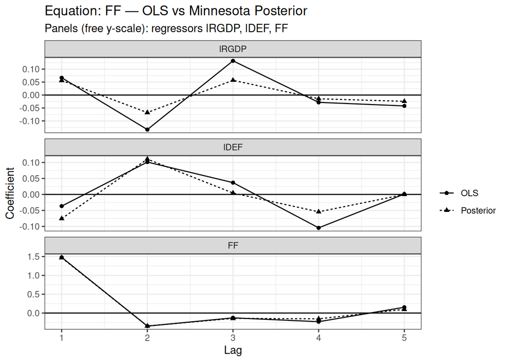

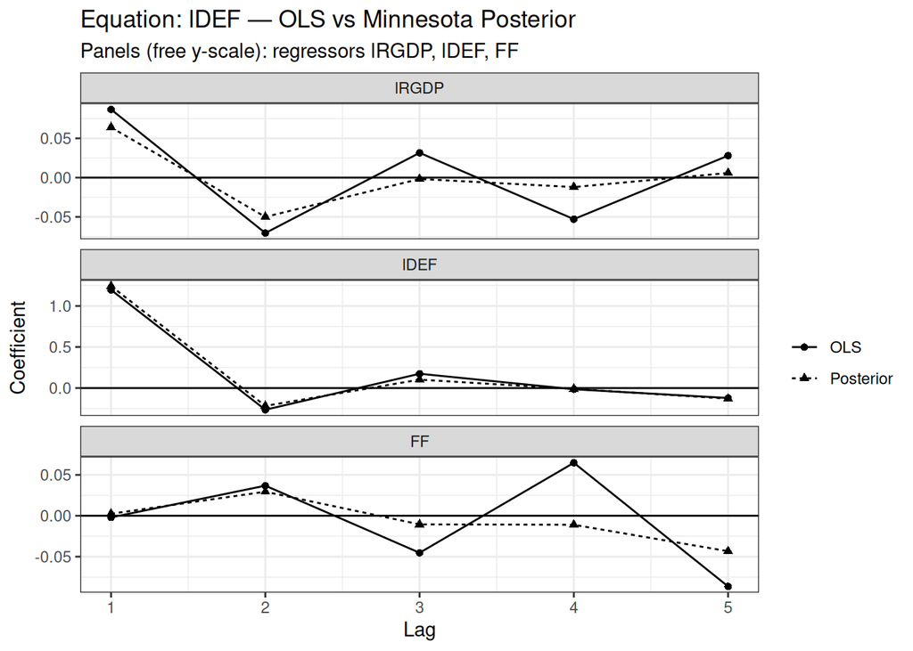

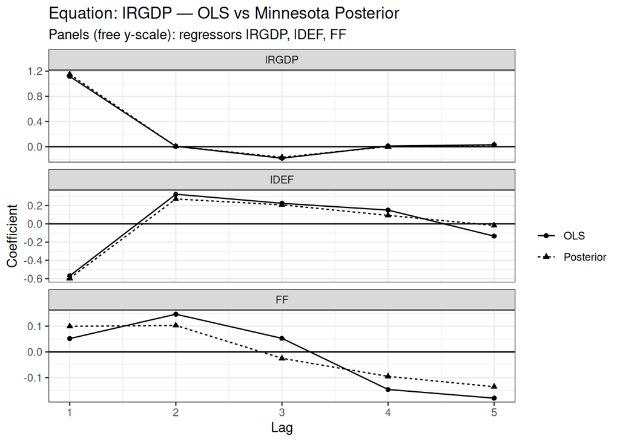

```r
# 1) OLSとPosteriorを縦持ちにする
df_ols <- as.data.frame(A_OLS) |>
  mutate(term = coef_names_A) |>
  pivot_longer(-term, names_to = "eq", values_to = "coef") |>
  mutate(method = "OLS")

df_post <- as.data.frame(A_Mn_post)
colnames(df_post) <- vars
df_post <- df_post |>
  mutate(term = coef_names_A) |>
  pivot_longer(-term, names_to = "eq", values_to = "coef") |>
  mutate(method = "Posterior")

df <- bind_rows(df_ols, df_post) |>
  # 定数は除外（ラグ軸に載らないので）
  filter(term != "const") |>
  # term から「説明変数」と「ラグ」を抽出（例: lRGDP.l3 -> var=lRGDP, lag=3）
  mutate(
    var = str_replace(term, "\\.l\\d+$", ""),
    lag = as.integer(str_extract(term, "(?<=\\.l)\\d+"))
  )

# 2) 3変数×3方程式（=9パネル）に絞る（必要なら）
# ここで var の順序を指定して見やすくする
var_levels <- c("lRGDP", "lDEF", "FF")
df <- df %>%
  mutate(
    var = factor(var, levels = var_levels),
    method = factor(method, levels = c("OLS", "Posterior"))
  )

# 方程式ごとにプロットを作って表示（3パネル：説明変数）
plots <- lapply(levels(factor(df$eq)), function(eq_i) {

  dfi <- df %>% filter(eq == eq_i)

  ggplot(dfi, aes(x = lag, y = coef, linetype = method, shape = method, group = method)) +
    geom_hline(yintercept = 0) +
    geom_line() +
    geom_point(size = 1.6) +
    scale_x_continuous(breaks = sort(unique(dfi$lag))) +
    facet_wrap(~ var, nrow = 3, scales = "free_y") +
    labs(
      x = "Lag",
      y = "Coefficient",
      linetype = "",
      shape = "",
      title = paste0("Equation: ", eq_i, " — OLS vs Minnesota Posterior"),
      subtitle = "Panels (free y-scale): regressors lRGDP, lDEF, FF"
    ) +
    theme_bw()
})

# すべて表示
for (g in plots) print(g)
```

## 4.3 ミネソタ事前分布（ダミー観測値）

### 4.3.1 マッピング

VAR($p$) モデルのベクトル化（再掲）は、

$$y = \underbrace{(I_M \otimes X)}_{TM\times KM} \alpha + \varepsilon,
\qquad \varepsilon \sim N(0,\; \underbrace{\Sigma}_{M\times M}\otimes
I_T) \tag{5.2.9}$$

Kilian and Lütkepohl (2016) のとおり、係数ベクトル $\alpha = \mathrm{vec}(A)$ に対する正規事前分布は、次の **dummy observation（mixed estimation）形式**で表現できる：

$$\underbrace{C}_{KM\times KM}\alpha = \underbrace{c}_{KM\times 1} + e,
\qquad e \sim N(0, I) \tag{5.2.8}$$

- $C$ ：事前分散行列の精度に対応する行列
- $c$ ：事前平均に対応するベクトル

事前分布$\alpha \sim N(\underline{\alpha}_{Mn}, \underline{V}_{Mn})$と次ように対応づける：

$$\underline{V}_{Mn} = (C'C)^{-1}, \qquad \underline{\alpha}_{Mn} =
C^{-1}c.$$

すなわち、
$$C = \underline{V}_{Mn}^{-1/2}, \qquad c = C\underline{\alpha}_{Mn}$$

```r
Cinv <- chol(V_Mn)
# round(Cinv %*% (t(Cinv)),4)==round(V_Mn,4)
C <- solve(Cinv)
c <- C %*% alpha_Mn
```

### 4.3.2 拡張回帰

上のマッピングを用いると、対応するMinnesota Priorの事後分布は下記のように書き換えられる。

$$\begin{aligned}
\bar{V}_{Mn} &=
\left(\underbrace{C'C}_{\underline{V}_{Mn}^{-1}}+ \underbrace{(\Sigma^{-1}\otimes
X'X)}_{\text{likelihoodprecision}}\right)^{-1}\\
\bar{\alpha}_{Mn} &= \bar{V}_{Mn}
\left(\underbrace{C'c}_{\underline{V}_{Mn}^{-1}\underline{\alpha}_{Mn}}+
(\Sigma^{-1}\otimes X')y \right).
\end{aligned}$$

これは、**prior を dummy observation として加えた拡張回帰モデルのGLS推定量**である。すなわち、Minnesota prior を用いた Bayesian VAR は、

> **「本来のデータに、prior に由来する dummy observation を加えた GLS 推定」**

として解釈できる。

$$\begin{aligned}
\underbrace{\begin{bmatrix}y \\ c\end{bmatrix}}_{(TM+KM)\times 1}
&= \underbrace{ \begin{bmatrix} I_M \otimes X \\ C \end{bmatrix}
}_{(TM+KM)\times KM} \alpha + \underbrace{ \begin{bmatrix} \varepsilon
\\ e \end{bmatrix} }_{(TM+KM)\times 1}, \\
\begin{bmatrix} \varepsilon \\ e \end{bmatrix} &\sim
N\!\left( 0,\; \underbrace{ \begin{bmatrix} \Sigma \otimes I_T & 0
\\ 0 & I \end{bmatrix} }_{\Omega} \right).
\end{aligned}$$

### 4.3.3 R コード

```r
# dummy data matrix
y_dum <- rbind(matrix(y, ncol = 1), c)
Xbig_dum <- rbind(Xbig, C)

n_data  <- length(y)     # = TT*M
n_prior <- nrow(C)       # = K*M

# vcov matrix
Omega_data_inv  <- kronecker(solve(Omega_Mn), diag(TT))
Omega_prior_inv <- diag(n_prior)
Omega_inv <- matrix(0, n_data + n_prior, n_data + n_prior)
Omega_inv[1:n_data, 1:n_data] <- Omega_data_inv
Omega_inv[(n_data+1):(n_data+n_prior), (n_data+1):(n_data+n_prior)] <- Omega_prior_inv
```

```r
# GLS estimator on augmented system
# alpha_gls = (X' Ω^{-1} X)^{-1} X' Ω^{-1} y
Xt_Oinv <- t(Xbig_dum) %*% Omega_inv
alpha_Mn_gls_dummy <- solve(Xt_Oinv %*% Xbig_dum, Xt_Oinv %*% y_dum)

# compare with closed-form posterior mean
diff_vec <- as.vector(alpha_Mn_post - alpha_Mn_gls_dummy)
cat("Max abs diff (closed-form vs GLS dummy): ", max(abs(diff_vec)), "\n")
cat("Mean abs diff: ", mean(abs(diff_vec)), "\n")

# optional: reshape to K x M for readability
A_Mn_gls_dummy <- matrix(as.vector(alpha_Mn_gls_dummy), nrow = K, ncol = M, byrow = FALSE)
colnames(A_Mn_gls_dummy) <- vars
rownames(A_Mn_gls_dummy) <- coef_names_A
```

```
## Max abs diff (closed-form vs GLS dummy):  1.408236e-05
## Mean abs diff:  3.512861e-07
```

## 4.4 Sum-of-coefficients prior

*Loosely speaking, the objective of these additional priors is to reduce the importance of the determin- istic component implied by the VARs estimated conditioning on the initial observations (Sims, 1992a)* (GLP 2015, p 440)

The setting follows Kilian and Lutkepohl (2016, pp159).

```r
mu_soc <- colMeans(df_var[(1:p) ,vars])
tau_soc <- 1
Ydum_soc <- diag(mu_soc)/tau_soc
Xdum_soc <- t(rbind(matrix(0, nrow = 1, ncol = M), kronecker(matrix(1, nrow = p, ncol = 1), diag(mu_soc)/tau_soc)))
```

今回の例では、以下のようなダミーが設定される。

- $Y \, (M \times K \, \text{or} \,3 \times 3)$

```r
print(Ydum_soc)
```

```
##          [,1]    [,2]  [,3]
## [1,] 934.5987   0.000 0.000
## [2,]   0.0000 420.614 0.000
## [3,]   0.0000   0.000 5.742
```

- $X \, (M \times K \, \text{or} \,3 \times 16)$

```r
print(Xdum_soc)
```

```
##      [,1]     [,2]    [,3]  [,4]     [,5]    [,6]  [,7]     [,8]    [,9] [,10]
## [1,]    0 934.5987   0.000 0.000 934.5987   0.000 0.000 934.5987   0.000 0.000
## [2,]    0   0.0000 420.614 0.000   0.0000 420.614 0.000   0.0000 420.614 0.000
## [3,]    0   0.0000   0.000 5.742   0.0000   0.000 5.742   0.0000   0.000 5.742
##         [,11]   [,12] [,13]    [,14]   [,15] [,16]
## [1,] 934.5987   0.000 0.000 934.5987   0.000 0.000
## [2,]   0.0000 420.614 0.000   0.0000 420.614 0.000
## [3,]   0.0000   0.000 5.742   0.0000   0.000 5.742
```

posterior は以下の通り。

```r
Y_soc <- rbind(Y, Ydum_soc)
X_soc <- rbind(X, Xdum_soc)
A_soc <- solve(t(X_soc) %*% X_soc) %*% t(X_soc) %*% Y_soc
colnames(A_soc) <- vars
```

ルーティン化するため `estimate_A_soc` を定義（のちにも使用）

```r
estimate_A_soc <- function(train_df, vars, p, tau = 1) {
  vm <- make_varmat_KK(train_df, vars = vars, p = p, add_const = TRUE)
  X <- vm$X; Y <- vm$Y
  M <- length(vars)

  mu <- colMeans(train_df[1:p, vars, drop=FALSE])
  Yd <- rbind(Y, diag(mu)/tau)
  Xd <- rbind(X,
              t(rbind(matrix(0, nrow=1, ncol=M),
                      kronecker(matrix(1, nrow=p, ncol=1), diag(mu)/tau))))

  A <- solve(crossprod(Xd), crossprod(Xd, Yd))
  colnames(A) <- vars
  A
}
```

### 4.4.1 $\tau$ の役割

- $\tau$が小さい（e.g. $10^{-4}$）→prior影響の影響大→**自己ラグの係数の和が1に近づく**
- $\tau$が大きい（e.g. $10^4$）→prior影響の影響小→OLSに近づく

```r
A_soc_bigtau <- estimate_A_soc(df_var, vars, p, tau = 10^4)
A_soc_smalltau <- estimate_A_soc(df_var, vars, p, tau = 10^(-4))
```

```r
tibble(
  Equation = rep(vars, each = K),
  Coef = rep(coef_names_A, M),
  `tau = 1 `= as.vector(A_soc),
  `small tau`= as.vector(A_soc_smalltau),
  `big tau`= as.vector(A_soc_bigtau),
  OLS = as.vector(alpha_OLS)) %>%
  mutate(Coef = factor(Coef, levels = coef_names_byvars)) %>%
  arrange(Coef) %>%
  group_by(Equation) %>%
  gt_basic(title = "推計結果（SOC prior v.s. OLS）", decimals = 2) %>%
  tab_spanner(columns = c(3:5), label = "SOC prior")
```

推計結果（SOC prior v.s. OLS）

| Coef | SOC prior tau = 1 | SOC prior small tau | SOC prior big tau | OLS |  |
| --- | --- | --- | --- | --- | --- |
| lRGDP |  |  |  |  |  |
| lRGDP.l1 | 1.21 | 1.23 | 1.12 |  | 1.12 |
| lRGDP.l2 | −0.03 | −0.02 | 0.01 | 0.01 |  |
| lRGDP.l3 | −0.19 | −0.20 | −0.18 | −0.18 |  |
| lRGDP.l4 | 0.01 | 0.02 | 0.01 | 0.01 |  |
| lRGDP.l5 | −0.01 | −0.03 | 0.03 | 0.03 |  |
| lDEF.l1 | −0.54 | −0.55 | −0.57 | −0.57 |  |
| lDEF.l2 | 0.31 | 0.33 | 0.32 | 0.32 |  |
| lDEF.l3 | 0.22 | 0.23 | 0.22 | 0.22 |  |
| lDEF.l4 | 0.05 | 0.09 | 0.15 | 0.15 |  |
| lDEF.l5 | −0.05 | −0.11 | −0.13 | −0.13 |  |
| FF.l1 | 0.13 | 0.08 | 0.05 | 0.05 |  |
| FF.l2 | 0.10 | 0.14 | 0.15 | 0.15 |  |
| FF.l3 | −0.04 | −0.05 | 0.05 | 0.05 |  |
| FF.l4 | −0.23 | −0.23 | −0.15 | −0.15 |  |
| FF.l5 | 0.06 | 0.06 | −0.18 | −0.18 |  |
| const | 1.09 | 0.63 | 18.65 | 18.65 |  |
| lDEF |  |  |  |  |  |
| lRGDP.l1 | 0.09 | 0.09 | 0.09 | 0.09 |  |
| lRGDP.l2 | −0.09 | −0.09 | −0.07 | −0.07 |  |
| lRGDP.l3 | 0.03 | 0.03 | 0.03 | 0.03 |  |
| lRGDP.l4 | −0.05 | −0.05 | −0.05 | −0.05 |  |
| lRGDP.l5 | 0.01 | 0.02 | 0.03 | 0.03 |  |
| lDEF.l1 | 1.32 | 1.32 | 1.20 | 1.20 |  |
| lDEF.l2 | −0.30 | −0.31 | −0.26 | −0.26 |  |
| lDEF.l3 | 0.16 | 0.15 | 0.17 | 0.17 |  |
| lDEF.l4 | −0.04 | −0.05 | −0.02 | −0.02 |  |
| lDEF.l5 | −0.13 | −0.11 | −0.12 | −0.12 |  |
| FF.l1 | 0.02 | 0.03 | 0.00 | 0.00 |  |
| FF.l2 | 0.03 | 0.02 | 0.04 | 0.04 |  |
| FF.l3 | −0.06 | −0.06 | −0.05 | −0.05 |  |
| FF.l4 | 0.03 | 0.03 | 0.06 | 0.06 |  |
| FF.l5 | −0.02 | −0.02 | −0.09 | −0.09 |  |
| const | 0.16 | 0.12 | −8.08 | −8.08 |  |
| FF |  |  |  |  |  |
| lRGDP.l1 | 0.09 | 0.07 | 0.07 | 0.07 |  |
| lRGDP.l2 | −0.14 | −0.15 | −0.13 | −0.13 |  |
| lRGDP.l3 | 0.13 | 0.14 | 0.13 | 0.13 |  |
| lRGDP.l4 | −0.03 | −0.03 | −0.03 | −0.03 |  |
| lRGDP.l5 | −0.05 | −0.02 | −0.04 | −0.04 |  |
| lDEF.l1 | −0.03 | −0.01 | −0.04 | −0.04 |  |
| lDEF.l2 | 0.09 | 0.06 | 0.10 | 0.10 |  |
| lDEF.l3 | 0.03 | 0.02 | 0.04 | 0.04 |  |
| lDEF.l4 | −0.14 | −0.20 | −0.10 | −0.10 |  |
| lDEF.l5 | 0.04 | 0.13 | 0.00 | 0.00 |  |
| FF.l1 | 1.51 | 1.60 | 1.48 | 1.48 |  |
| FF.l2 | −0.37 | −0.42 | −0.35 | −0.35 |  |
| FF.l3 | −0.16 | −0.15 | −0.13 | −0.13 |  |
| FF.l4 | −0.26 | −0.26 | −0.23 | −0.23 |  |
| FF.l5 | 0.23 | 0.24 | 0.15 | 0.15 |  |
| const | 0.02 | −0.05 | 5.47 | 5.47 |  |

## 4.5 Innitial dummy observations prior

（セットアップの解説）

The setting follows Kilian and Lutkepohl (2016, pp159).

```r
mu_dobs <- colMeans(df_var[(1:p) ,vars])
tau_dobs <- 1
Ydum_dobs <- mu_dobs/tau_dobs
Xdum_dobs <- c(1, rep(mu_dobs/tau_dobs, p))
```

今回の例では、以下のようなダミーが設定される。

- $Y \, (M \times K \, \text{or} \,1 \times 3)$

```r
print(Ydum_dobs)
```

```
##    lRGDP     lDEF       FF
## 934.5987 420.6140   5.7420
```

- $X \, (M \times K \, \text{or} \,1 \times 16)$

```r
print(Xdum_dobs)
```

```
##             lRGDP     lDEF       FF    lRGDP     lDEF       FF    lRGDP
##   1.0000 934.5987 420.6140   5.7420 934.5987 420.6140   5.7420 934.5987
##     lDEF       FF    lRGDP     lDEF       FF    lRGDP     lDEF       FF
## 420.6140   5.7420 934.5987 420.6140   5.7420 934.5987 420.6140   5.7420
```

posterior は以下の通り。

```r
Y_dobs <- rbind(Y, Ydum_dobs)
X_dobs <- rbind(X, Xdum_dobs)
A_dobs <- solve(t(X_dobs) %*% X_dobs) %*% t(X_dobs) %*% Y_dobs
colnames(A_dobs) <- vars
```

ルーティン化するため `estimate_A_dobs` を定義（のちにも使用）

```r
estimate_A_dobs <- function(train_df, vars, p, tau = 1) {
  vm <- make_varmat_KK(train_df, vars = vars, p = p, add_const = TRUE)
  X <- vm$X; Y <- vm$Y
  M <- length(vars)

  # KL dummy observations prior (dummy obs)
  # use the first p observations *in Y* (i.e. after removing initial lags)
  mu <- colMeans(train_df[1:p, vars, drop = FALSE])

  Y_dobs <- rbind(Y, matrix(mu / tau, nrow = 1))
  X_dobs <- rbind(X, matrix(c(1, rep(mu / tau, p)), nrow = 1))

  A <- solve(crossprod(X_dobs), crossprod(X_dobs, Y_dobs))
  colnames(A) <- vars
  A
}
```

### 4.5.1 $\tau$ の役割

```r
A_dobs_bigtau <- estimate_A_dobs(df_var, vars, p, tau = 10^4)
A_dobs_smalltau <- estimate_A_dobs(df_var, vars, p, tau = 10^(-4))
```

```r
tibble(
  Equation = rep(vars, each = K),
  Coef = rep(coef_names_A, M),
  `tau = 1 `= as.vector(A_dobs),
  `small tau`= as.vector(A_dobs_smalltau),
  `big tau`= as.vector(A_dobs_bigtau),
  OLS = as.vector(alpha_OLS)) %>%
  mutate(Coef = factor(Coef, levels = coef_names_byvars)) %>%
  arrange(Coef) %>%
  group_by(Equation) %>%
  gt_basic(title = "推計結果（Dummy Obs. prior v.s. OLS）", decimals = 2) %>%
  tab_spanner(columns = c(3:5), label = "Dummy Obs. prior")
```

推計結果（Dummy Obs. prior v.s. OLS）

| Coef | Dummy Obs. prior tau = 1 | Dummy Obs. prior small tau | Dummy Obs. prior big tau | OLS |  |
| --- | --- | --- | --- | --- | --- |
| lRGDP |  |  |  |  |  |
| lRGDP.l1 | 1.17 | 1.15 | 1.15 |  | 1.12 |
| lRGDP.l2 | −0.01 | 0.01 | 0.01 | 0.01 |  |
| lRGDP.l3 | −0.20 | −0.18 | −0.18 | −0.18 |  |
| lRGDP.l4 | 0.01 | 0.00 | 0.01 | 0.01 |  |
| lRGDP.l5 | 0.01 | 0.03 | 0.03 | 0.03 |  |
| lDEF.l1 | −0.54 | −0.71 | −0.71 | −0.57 |  |
| lDEF.l2 | 0.35 | 0.36 | 0.37 | 0.32 |  |
| lDEF.l3 | 0.24 | 0.26 | 0.25 | 0.22 |  |
| lDEF.l4 | 0.17 | 0.12 | 0.14 | 0.15 |  |
| lDEF.l5 | −0.23 | −0.07 | −0.08 | −0.13 |  |
| FF.l1 | 0.00 | 0.07 | 0.06 | 0.05 |  |
| FF.l2 | 0.18 | 0.13 | 0.14 | 0.15 |  |
| FF.l3 | 0.03 | 0.04 | 0.03 | 0.05 |  |
| FF.l4 | −0.18 | −0.13 | −0.14 | −0.15 |  |
| FF.l5 | −0.11 | −0.17 | −0.16 | −0.18 |  |
| const | 14.72 | 1.08 | 0.05 | 18.65 |  |
| lDEF |  |  |  |  |  |
| lRGDP.l1 | 0.09 | 0.07 | 0.07 | 0.09 |  |
| lRGDP.l2 | −0.07 | −0.07 | −0.07 | −0.07 |  |
| lRGDP.l3 | 0.03 | 0.03 | 0.03 | 0.03 |  |
| lRGDP.l4 | −0.05 | −0.05 | −0.05 | −0.05 |  |
| lRGDP.l5 | 0.03 | 0.03 | 0.03 | 0.03 |  |
| lDEF.l1 | 1.20 | 1.26 | 1.26 | 1.20 |  |
| lDEF.l2 | −0.26 | −0.28 | −0.28 | −0.26 |  |
| lDEF.l3 | 0.17 | 0.16 | 0.16 | 0.17 |  |
| lDEF.l4 | −0.01 | −0.01 | −0.01 | −0.02 |  |
| lDEF.l5 | −0.13 | −0.15 | −0.14 | −0.12 |  |
| FF.l1 | 0.00 | −0.01 | −0.01 | 0.00 |  |
| FF.l2 | 0.04 | 0.04 | 0.04 | 0.04 |  |
| FF.l3 | −0.05 | −0.04 | −0.04 | −0.05 |  |
| FF.l4 | 0.06 | 0.06 | 0.06 | 0.06 |  |
| FF.l5 | −0.08 | −0.09 | −0.09 | −0.09 |  |
| const | −8.27 | 0.14 | −0.02 | −8.08 |  |
| FF |  |  |  |  |  |
| lRGDP.l1 | 0.06 | 0.08 | 0.08 | 0.07 |  |
| lRGDP.l2 | −0.13 | −0.13 | −0.13 | −0.13 |  |
| lRGDP.l3 | 0.13 | 0.13 | 0.13 | 0.13 |  |
| lRGDP.l4 | −0.03 | −0.03 | −0.03 | −0.03 |  |
| lRGDP.l5 | −0.04 | −0.04 | −0.04 | −0.04 |  |
| lDEF.l1 | −0.04 | −0.08 | −0.08 | −0.04 |  |
| lDEF.l2 | 0.10 | 0.11 | 0.11 | 0.10 |  |
| lDEF.l3 | 0.04 | 0.04 | 0.04 | 0.04 |  |
| lDEF.l4 | −0.11 | −0.11 | −0.11 | −0.10 |  |
| lDEF.l5 | 0.02 | 0.02 | 0.02 | 0.00 |  |
| FF.l1 | 1.49 | 1.48 | 1.48 | 1.48 |  |
| FF.l2 | −0.35 | −0.35 | −0.35 | −0.35 |  |
| FF.l3 | −0.12 | −0.13 | −0.13 | −0.13 |  |
| FF.l4 | −0.22 | −0.23 | −0.23 | −0.23 |  |
| FF.l5 | 0.14 | 0.16 | 0.16 | 0.15 |  |
| const | 6.06 | −0.25 | 0.01 | 5.47 |  |

## 4.6 パフォーマンス比較 （OLS, Minnesota, SOC, Dummy Obs.)

```r
model_name <- c("OLS", "Minnesota", "SOC", "Dummy Obs.")
col_map <- c("#000000", "#1f77b4", "#ff7f0e", "#2ca02c","red")
names(col_map) <- c("Actual", model_name)
col_map_se <- col_map[c("OLS", "Minnesota", "SOC")]

lt_map <- c("solid", "solid", "dashed", "dotdash","dotdash")
names(lt_map) <- c("Actual", model_name)
lw_map <- c(1.2, 0.9, 0.9, 0.9, 0.9)
names(lw_map) <- c("Actual", model_name)
```

### 4.6.1 フィットと先行きのパス

```r
# forecastを計算
make_var_fit_forecast <- function(df, date_col = "date", vars, p, A, h = 40, add_const = TRUE) {
  stopifnot(all(c(date_col, vars) %in% names(df)))
  stopifnot(is.matrix(A))
  stopifnot(ncol(A) == length(vars))

  df <- df |> arrange(.data[[date_col]])
  Ymat <- as.matrix(df[, vars, drop = FALSE])
  T_df <- nrow(Ymat)
  M <- length(vars)
  K <- (if (add_const) 1L else 0L) + M * p
  stopifnot(nrow(A) == K)

  # 1行の regressor を作る：x_t = (1, vec([y_{t-1},...,y_{t-p}])) の順（lagごとに vars を並べる）
  make_x <- function(lag_block) {
    # lag_block: p x M, rows = (t-1, t-2, ..., t-p), cols = vars
    x_no_const <- as.vector(t(lag_block))  # lag1の(vars順) -> lag2 -> ...（あなたの X と一致）
    if (add_const) c(1, x_no_const) else x_no_const
  }

  # --- in-sample fitted ---
  fitted <- matrix(NA_real_, nrow = T_df, ncol = M)
  for (t in (p + 1):T_df) {
    lag_block <- Ymat[(t - 1):(t - p), , drop = FALSE]
    x_t <- make_x(lag_block)
    fitted[t, ] <- as.numeric(x_t %*% A)
  }

  # --- recursive point forecast h-step ahead ---
  # 初期ラグは「最後の p 期の実績」を使う（必要なら fitted を使う版も作れるが、標準は実績）
  hist <- Ymat[(T_df):(T_df - p + 1), , drop = FALSE]  # rows: T, T-1, ... の順
  fc <- matrix(NA_real_, nrow = h, ncol = M)

  for (s in 1:h) {
    # make_x は rows=(t-1,...,t-p) を想定。hist は rows=(latest, ..., older) なのでそのまま使える
    x_s <- make_x(hist[1:p, , drop = FALSE])
    y_next <- as.numeric(x_s %*% A)
    fc[s, ] <- y_next
    hist <- rbind(y_next, hist)  # 先頭に追加してラグ更新
  }

  # 日付：四半期の末日が入っている前提で、次期以降を seq で作る
  last_date <- df[[date_col]][T_df]
  fc_dates <- seq(from = last_date, by = "quarter", length.out = h + 1)[-1]

  list(
    in_sample = tibble(
      date = df[[date_col]],
      !!!setNames(as.data.frame(Ymat), vars),
      !!!setNames(as.data.frame(fitted), paste0(vars, "_fitted"))
    ),
    forecast = tibble(
      date = fc_dates,
      !!!setNames(as.data.frame(fc), paste0(vars, "_forecast"))
    )
  )
}

# 1) 各手法の「fitted+forecast」を1本に結合した series を作る
mk_method_series <- function(res, method, vars) {
  # in-sample fitted: date, var_fitted
  df_fit <- res$in_sample |>
    dplyr::select(date, ends_with("_fitted")) |>
    pivot_longer(-date, names_to = "name", values_to = "value") |>
    mutate(var = str_remove(name, "_fitted")) |>
    dplyr::select(date, var, value)

  # forecast: date, var_forecast
  df_fc <- res$forecast |>
    pivot_longer(-date, names_to = "name", values_to = "value") |>
    mutate(var = str_remove(name, "_forecast")) |>
    dplyr::select(date, var, value)

  bind_rows(df_fit, df_fc) |>
    mutate(method = method)
}
```

#### 4.6.1.1 レベル

```r
h <- 40 # h = 1000でもSOCは収束しない（ダラダラと下がり続ける）

res_ols  <- make_var_fit_forecast(df_var, vars = vars, p = p, A = A_OLS,     h = h)
res_mn   <- make_var_fit_forecast(df_var, vars = vars, p = p, A = A_Mn_post, h = h)
res_soc  <- make_var_fit_forecast(df_var, vars = vars, p = p, A = A_soc,  h = h)
res_dobs  <- make_var_fit_forecast(df_var, vars = vars, p = p, A = A_dobs,  h = h)

df_actual <- df_var |>
  dplyr::select(date, all_of(vars)) |>
  pivot_longer(-date, names_to = "var", values_to = "value") |>
  mutate(method = "Actual")

df_ols_series <- mk_method_series(res_ols, model_name[1], vars)
df_mn_series  <- mk_method_series(res_mn,  model_name[2], vars)
df_soc_series <- mk_method_series(res_soc, model_name[3], vars)
df_dobs_series <- mk_method_series(res_dobs, model_name[4], vars)

df_fcst_all <- bind_rows(
  df_actual,
  df_ols_series,
  df_mn_series,
  df_soc_series,
  df_dobs_series
) |>
  mutate(
    var = factor(var, levels = vars),
    method = factor(method, levels = c("Actual", model_name))
  )
```

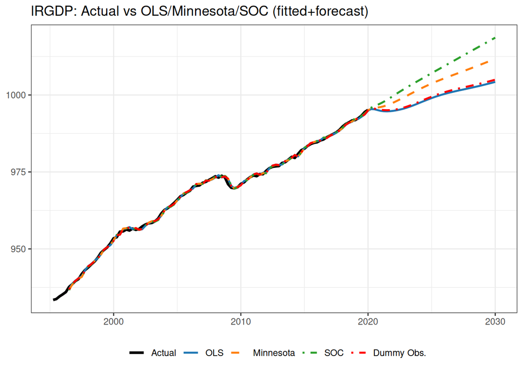

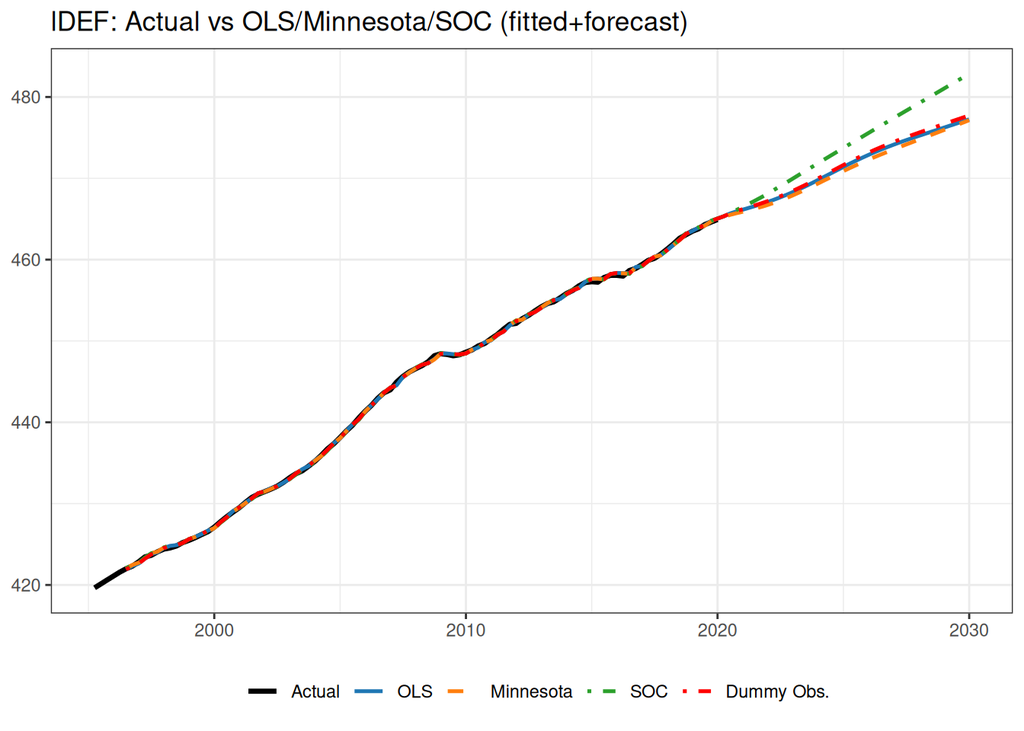

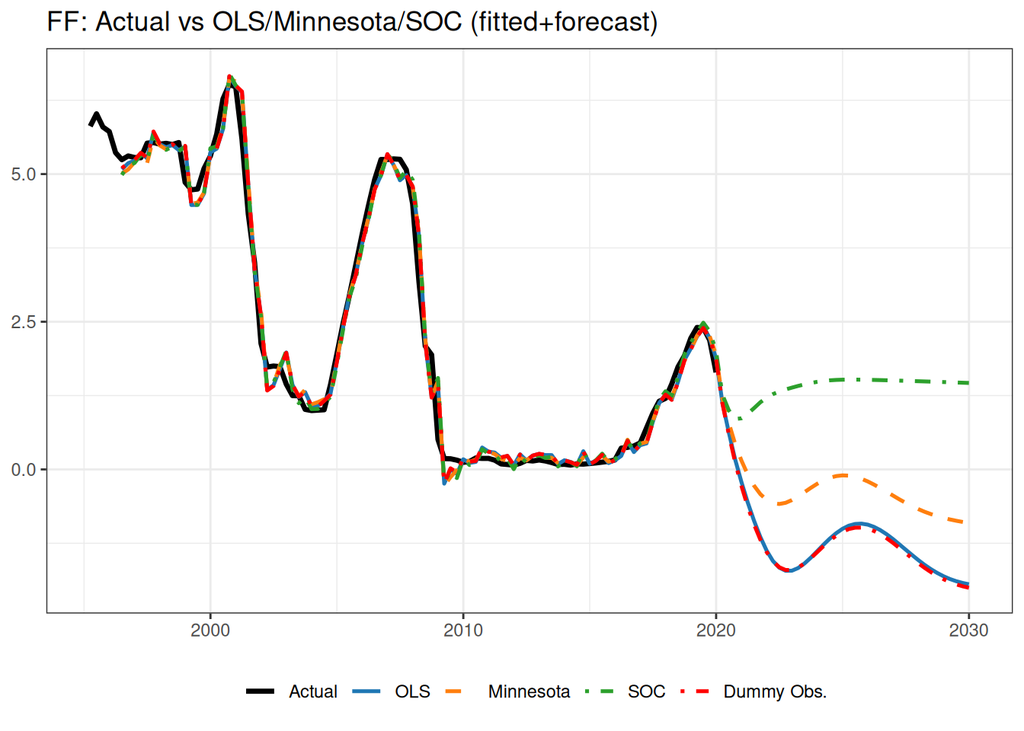

```r
plots_3 <- lapply(levels(df_fcst_all$var), function(v) {
  dfi <- df_fcst_all |> dplyr::filter(var == v)

  ggplot(dfi, aes(x = date, y = value, color = method, linetype = method, linewidth = method)) +
    geom_line() +
    scale_color_manual(values = col_map) +
    scale_linetype_manual(values = lt_map) +
    scale_linewidth_manual(values = lw_map) +
    labs(
      title = paste0(v, ": Actual vs OLS/Minnesota/SOC (fitted+forecast)"),
      x = NULL, y = NULL, color = "", linetype = "", linewidth = ""
    ) +
    theme_bw() +
    theme(legend.position = "bottom")
})

for (g in plots_3) print(g)
```

#### 4.6.1.2 差分

```r
# 3つのフィットの R^2 を計算（GDP/物価=階差、金利=レベル）

# R^2 helper（NAは落とす）
calc_r2 <- function(y, yhat) {
  ok <- is.finite(y) & is.finite(yhat)
  y <- y[ok]; yhat <- yhat[ok]
  if (length(y) < 3) return(NA_real_)
  sse <- sum((y - yhat)^2)
  sst <- sum((y - mean(y))^2)
  if (sst == 0) return(NA_real_)
  1 - sse / sst
}

# in-sample の actual と fitted だけを取り出して R^2 を作る
# - lRGDP, lDEF は diff（成長率）
# - FF は level
make_r2_table <- function(df_var, vars,
                          res_ols, res_mn, res_soc,
                          date_col = "date") {

  # actual (T x M)
  act <- as.matrix(df_var[, vars, drop = FALSE])

  # fitted (T x M) : res$in_sample の *_fitted を列順で取る
  get_fit_mat <- function(res) {
    mat <- as.matrix(res$in_sample[, paste0(vars, "_fitted"), drop = FALSE])
    colnames(mat) <- vars
    mat
  }

  fit_ols <- get_fit_mat(res_ols)
  fit_mn  <- get_fit_mat(res_mn)
  fit_soc <- get_fit_mat(res_soc)

  # 変換：diff する変数
  diff_vars <- intersect(c("lRGDP", "lDEF"), vars)

  # 各変数ごとに R^2
  out <- lapply(vars, function(v) {
    y    <- act[, v]
    yhat_ols <- fit_ols[, v]
    yhat_mn  <- fit_mn[, v]
    yhat_soc <- fit_soc[, v]

    if (v %in% diff_vars) {
      y        <- c(NA_real_, diff(y))
      yhat_ols <- c(NA_real_, diff(yhat_ols))
      yhat_mn  <- c(NA_real_, diff(yhat_mn))
      yhat_soc <- c(NA_real_, diff(yhat_soc))
    }

    tibble::tibble(
      var = v,
      R2_OLS = calc_r2(y, yhat_ols),
      R2_Minnesota = calc_r2(y, yhat_mn),
      R2_SOC = calc_r2(y, yhat_soc)
    )
  })

  dplyr::bind_rows(out)
}
```

```r
r2_tbl <- make_r2_table(
  df_var = df_var,
  vars   = vars,
  res_ols = res_ols,
  res_mn  = res_mn,
  res_soc = res_soc
)
```

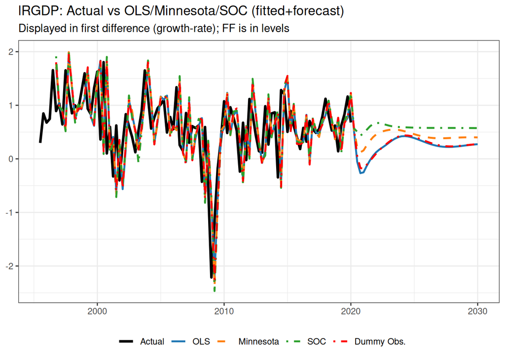

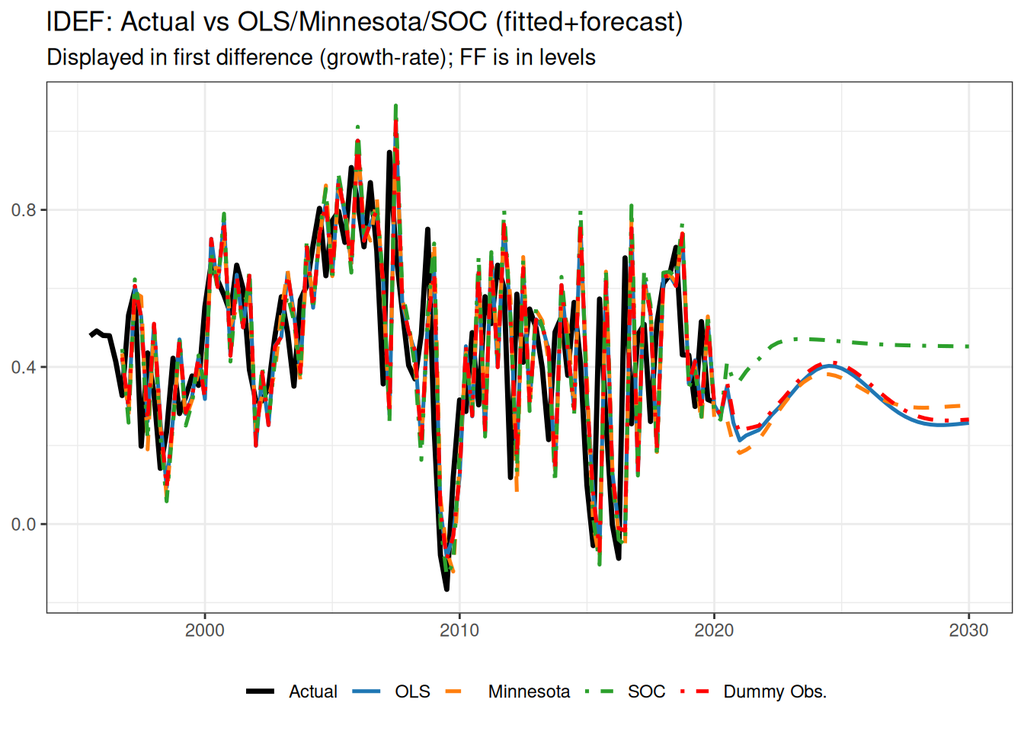

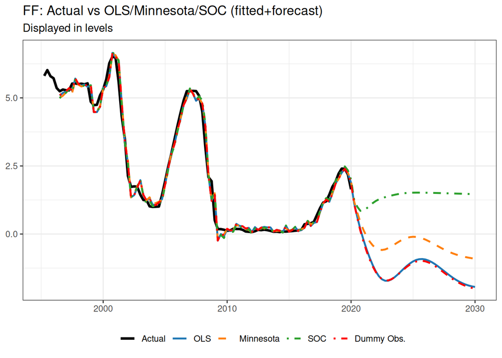

```r
diff_vars <- intersect(c("lRGDP", "lDEF"), levels(df_fcst_all$var))

df_fcst_all_trans <- df_fcst_all |>
  dplyr::arrange(var, method, date) |>
  dplyr::group_by(var, method) |>
  dplyr::mutate(
    value_trans = dplyr::if_else(
      var %in% diff_vars,
      value - dplyr::lag(value),
      value
    )
  ) |>
  dplyr::ungroup() |>
  dplyr::filter(!(var %in% diff_vars & is.na(value_trans))) |>
  dplyr::mutate(value = value_trans) |>
  dplyr::select(-value_trans)

# 3枚（変数ごと）プロット
plots_3_trans <- lapply(levels(df_fcst_all_trans$var), function(v) {
  dfi <- df_fcst_all_trans |> dplyr::filter(var == v)

  ggplot(dfi, aes(x = date, y = value, color = method, linetype = method, linewidth = method)) +
    geom_line() +
    scale_color_manual(values = col_map) +
    scale_linetype_manual(values = lt_map) +
    scale_linewidth_manual(values = lw_map) +
    labs(
      title = paste0(v, ": Actual vs OLS/Minnesota/SOC (fitted+forecast)"),
      subtitle = if (v %in% diff_vars) "Displayed in first difference (growth-rate); FF is in levels" else "Displayed in levels",
      x = NULL, y = NULL, color = "", linetype = "", linewidth = ""
    ) +
    theme_bw() +
    theme(legend.position = "bottom")
})

for (g in plots_3_trans) print(g)
```

#### 4.6.1.3 長期予測値と最大固有値

SOCを除く各priorでは、長期予測値が波を打ちながら大きく変動する→Sims (1992) の「初期値問題」（Dummy Obs. でも初期値問題は緩和されるはずだが…）

なお、収束の速さは最大固有値からわかる

```r
# Max eigenvalue (spectral radius) of a VAR(p) companion matrix
# Input:
#   A  : K x M matrix (rows = regressors [const, lags...], cols = equations)
#        This matches your A_OLS, A_Mn_post, A_soc style.
#   p  : lag order
#   M  : number of variables
#   add_const : whether the first row of A is const
# Output:
#   list(rho = max |lambda|, eig = eigenvalues, companion = F)

var_max_eig <- function(A, p, M, add_const = TRUE, return_companion = FALSE) {
  A <- as.matrix(A)
  K_expected <- (if (add_const) 1L else 0L) + M * p
  stopifnot(nrow(A) == K_expected, ncol(A) == M)

  # --- Extract lag coefficient matrices A1..Ap as M x M ---
  # Your A is K x M with rows: const, (lag1 vars), ..., (lagp vars)
  # Each lag block in A is M rows (vars), M cols (equations) => transpose to (equations x vars) = M x M.
  A_lags <- vector("list", p)
  for (r in 1:p) {
    row_start <- (if (add_const) 2L else 1L) + (r - 1L) * M
    row_end   <- row_start + M - 1L
    B <- A[row_start:row_end, , drop = FALSE]  # rows: vars, cols: equations
    A_lags[[r]] <- t(B)                        # rows: equations, cols: vars  => M x M
  }

  # --- Build companion matrix F of size (Mp) x (Mp) ---
  Mp <- M * p
  F <- matrix(0, nrow = Mp, ncol = Mp)

  # top block row: [A1 A2 ... Ap]
  F[1:M, 1:Mp] <- do.call(cbind, A_lags)

  # subdiagonal identity blocks
  if (p >= 2) {
    F[(M + 1):Mp, 1:(Mp - M)] <- diag(Mp - M)
  }

  # --- Eigenvalues and spectral radius ---
  eigvals <- eigen(F, only.values = TRUE)$values
  rho <- max(Mod(eigvals))

  out <- list(rho = rho, eig = eigvals)
  if (return_companion) out$companion <- F
  out
}

# just the max |eig|
var_spectral_radius <- function(A, p, M, add_const = TRUE) {
  var_max_eig(A, p = p, M = M, add_const = add_const)$rho
}
```

```r
# Example:
rho_ols <- var_spectral_radius(A_OLS, p = p, M = M, add_const = TRUE)
rho_mn  <- var_spectral_radius(A_Mn_post, p = p, M = M, add_const = TRUE)
rho_soc <- var_spectral_radius(A_soc, p = p, M = M, add_const = TRUE)
rho_dobs <- var_spectral_radius(A_dobs, p = p, M = M, add_const = TRUE)
```

```r
print(c(rho_ols, rho_mn, rho_soc, rho_dobs) %>% `names<-`(model_name))
```

```
##        OLS  Minnesota        SOC Dummy Obs.
##  0.9924795  0.9998453  0.9999174  0.9926750
```

### 4.6.2 Out-of-sample 予測

```r
#  1-step forecast given A and last p actuals
var_1step_fc <- function(train_df, vars, p, A, add_const = TRUE) {
  Ymat <- as.matrix(train_df[, vars, drop = FALSE])
  T_df <- nrow(Ymat); M <- length(vars)

  # last p obs: rows = (t, t-1, ..., t-p+1)
  hist <- Ymat[T_df:(T_df - p + 1), , drop = FALSE]

  x_no_const <- as.vector(t(hist))   # lag1 vars -> lag2 vars -> ...
  x <- if (add_const) c(1, x_no_const) else x_no_const

  drop(x %*% A)  # length M
}

estimate_A_ols <- function(train_df, vars, p) {
  vm <- make_varmat_KK(train_df, vars = vars, p = p, add_const = TRUE)
  X <- vm$X; Y <- vm$Y
  solve(crossprod(X), crossprod(X, Y))
}

estimate_A_mn_post <- function(train_df, vars, p, a1=1, a2=0.5, a3=0.1) {
  vm <- make_varmat_KK(train_df, vars = vars, p = p, add_const = TRUE)
  X <- vm$X; Y <- vm$Y; y <- vm$y
  TT <- nrow(Y); M <- length(vars); K <- 1 + M*p

  # window OLS Sigma
  A_ols <- solve(crossprod(X), crossprod(X, Y))
  U <- Y - X %*% A_ols
  Omega_hat <- crossprod(U) / (TT - K)

  # Minnesota prior mean (general M)
  alpha0 <- matrix(0, M*K, 1)
  idx_ownlag1 <- (0:(M-1))*K + (1 + (1:M))
  alpha0[idx_ownlag1] <- 1

  # Minnesota prior variance diag (general M)
  Vdiag <- rep(NA_real_, M*K)
  V_r <- c(1, rep((1:p)^(-2), each = M))

  for (i in 1:M) {
    tmp <- rep(NA_real_, K)
    tmp[1] <- (a3^2) * Omega_hat[i,i]  # const
    for (j in 1:M) {
      idx_j <- 1 + j + (0:(p-1))*M
      if (i == j) tmp[idx_j] <- (a1^2)
      else        tmp[idx_j] <- (a2^2) * (Omega_hat[i,i]/Omega_hat[j,j])
    }
    Vdiag[(1+(i-1)*K):(i*K)] <- V_r * tmp
  }

  Vinv <- diag(1/Vdiag)
  Oinv <- solve((Omega_hat + t(Omega_hat))/2)
  H <- Vinv + kronecker(Oinv, crossprod(X))
  b <- Vinv %*% alpha0 + kronecker(Oinv, t(X)) %*% y
  alpha_post <- solve(H, b)

  A_post <- matrix(as.vector(alpha_post), nrow = K, ncol = M, byrow = FALSE)
  colnames(A_post) <- vars
  A_post
}
```

```r
# estimate A by method on a given training set
estimate_A_ols_old <- function(train_df, vars, p) {
  vm <- make_varmat_KK(train_df, vars = vars, p = p, add_const = TRUE)
  X <- vm$X; Y <- vm$Y
  solve(crossprod(X), crossprod(X, Y))
}

estimate_A_mn_post_old <- function(train_df, vars, p, a1=1, a2=0.5, a3=0.1) {
  # build X,Y,y
  vm <- make_varmat_KK(train_df, vars = vars, p = p, add_const = TRUE)
  X <- vm$X; Y <- vm$Y; y <- vm$y
  TT <- nrow(Y); M <- length(vars); K <- 1 + M*p

  # OLS Sigma hat (window-specific!)
  A_ols <- solve(crossprod(X), crossprod(X, Y))
  U <- Y - X %*% A_ols
  Omega_hat <- crossprod(U) / (TT - K)

  # Minnesota prior mean alpha0 and Vdiag (あなたのロジックに合わせて作る)
  alpha0 <- matrix(0, M*K, 1)
  alpha0[c(0*K+1+1, 1*K+2+1, 2*K+3+1)] <- 1

  # IMPORTANT: a^2 が正しい（ここは直しておくのが筋）
  Vdiag <- rep(NA_real_, M*K)
  V_r <- c(1, rep((1:p)^(-2), each = M))

  for (i in 1:M) {
    tmp <- rep(NA_real_, K)
    tmp[1] <- (a3^2) * Omega_hat[i,i]
    for (j in 1:M) {
      idx_j <- 1 + j + (0:(p-1))*M
      if (i == j) tmp[idx_j] <- (a1^2)
      else        tmp[idx_j] <- (a2^2) * (Omega_hat[i,i]/Omega_hat[j,j])
    }
    Vdiag[(1+(i-1)*K):(i*K)] <- V_r * tmp
  }

  # posterior mean via solving linear system (avoid explicit inverses)
  Vinv <- diag(1/Vdiag)
  Oinv <- solve((Omega_hat + t(Omega_hat))/2)  # 必要なら jitter 版へ
  H <- Vinv + kronecker(Oinv, crossprod(X))
  b <- Vinv %*% alpha0 + kronecker(Oinv, t(X)) %*% y
  alpha_post <- solve(H, b)

  A_post <- matrix(as.vector(alpha_post), nrow = K, ncol = M, byrow = FALSE)
  colnames(A_post) <- vars
  A_post
}
```

```r
msfe_1step_expanding <- function(df_long, vars, p,
                                 train_start = as.Date("1980-01-01"),
                                 train_end0  = as.Date("1994-12-31"),
                                 model_name = c("OLS", "Minnesota", "SOC", "Dummy Obs."),
                                 mn_hyper = list(a1 = 1, a2 = 0.5, a3 = 0.1),
                                 soc_hyper = list(tau = 1),
                                 dobs_hyper = list(tau = 1)) {

  df_long <- df_long %>% arrange(date) %>% filter(train_start <= date)

  # expanding end dates: from train_end0 to last-1quarter
  end_dates <- df_long$date[df_long$date >= train_end0]
  end_dates <- end_dates[end_dates <= (max(df_long$date) %m-% months(3))]

  out <- vector("list", length(end_dates))

  for (ii in seq_along(end_dates)) {
    t_end <- end_dates[ii]

    train <- df_long %>% filter(date <= t_end)
    test_date <- t_end %m+% months(3)
    test <- df_long %>% filter(date == test_date)

    if (nrow(test) != 1) next
    if (nrow(train) < (p + 5)) next  # safety

    # --- estimate A ---
    A_ols  <- estimate_A_ols(train, vars, p)

    A_mn   <- do.call(
      estimate_A_mn_post,
      c(list(train_df = train, vars = vars, p = p), mn_hyper)
    )

    A_soc  <- do.call(
      estimate_A_soc,
      c(list(train_df = train, vars = vars, p = p), soc_hyper)
    )

    A_dobs <- do.call(
      estimate_A_dobs,
      c(list(train_df = train, vars = vars, p = p), dobs_hyper)
    )

    # --- 1-step point forecast ---
    fc_ols  <- var_1step_fc(train, vars, p, A_ols)
    fc_mn   <- var_1step_fc(train, vars, p, A_mn)
    fc_soc  <- var_1step_fc(train, vars, p, A_soc)
    fc_dobs <- var_1step_fc(train, vars, p, A_dobs)

    y_true <- as.numeric(test[1, vars])

    out[[ii]] <- tibble(
      date   = test_date,
      var    = vars,
      se_ols  = (y_true - fc_ols)^2,
      se_mn   = (y_true - fc_mn)^2,
      se_soc  = (y_true - fc_soc)^2,
      se_dobs = (y_true - fc_dobs)^2
    )
  }

  df_se <- bind_rows(out)

  df_msfe <- df_se %>%
    group_by(var) %>%
    summarize(
      MSFE_OLS        = mean(se_ols,  na.rm = TRUE),
      MSFE_Minnesota  = mean(se_mn,   na.rm = TRUE),
      MSFE_SOC        = mean(se_soc,  na.rm = TRUE),
      MSFE_DummyObs   = mean(se_dobs, na.rm = TRUE),
      .groups = "drop"
    )

  list(model_name = model_name, se = df_se, msfe = df_msfe)
}
```

```
## [1] 0.1
## [1] 0.2
## [1] 0.3
## [1] 0.4
## [1] 0.5
```

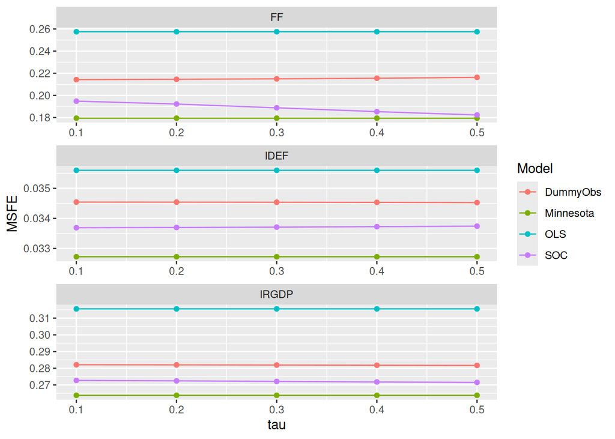

```r
msfe_table <- tibble()
for (tau_loop in c(1:5)/10){
  print(tau_loop)
  res_msfe <- msfe_1step_expanding(df_var_long, vars, p, soc_hyper = list(tau = tau_loop), dobs_hyper = list(tau_loop))
  msfe_table_loop <- mutate(res_msfe$msfe, tau = tau_loop)
  msfe_table <- bind_rows(msfe_table, msfe_table_loop)
}

msfe_table %>%
  pivot_longer(cols = c(-var, -tau), names_to = "Model", values_to = "MSFE") %>%
  mutate(Model = str_remove(Model, "MSFE_")) %>%
  ggplot(mapping = aes(x = tau, y = MSFE, color = Model)) +
  geom_line()+
  geom_point()+
  facet_wrap(~var, scales = "free", ncol = 1)
```

```r
res_msfe <- msfe_1step_expanding(df_var_long, vars, p)
df_se <- res_msfe$se
```

```r
res_msfe$msfe %>%
  gt_basic(title = "MSFE", decimals = 4)
```

MSFE

| var | MSFE_OLS | MSFE_Minnesota | MSFE_SOC | MSFE_DummyObs |
| --- | --- | --- | --- | --- |
| FF | 0.2575 | 0.1794 | 0.1766 | 0.2364 |
| lDEF | 0.0356 | 0.0327 | 0.0338 | 0.0353 |
| lRGDP | 0.3155 | 0.2638 | 0.2711 | 0.3113 |

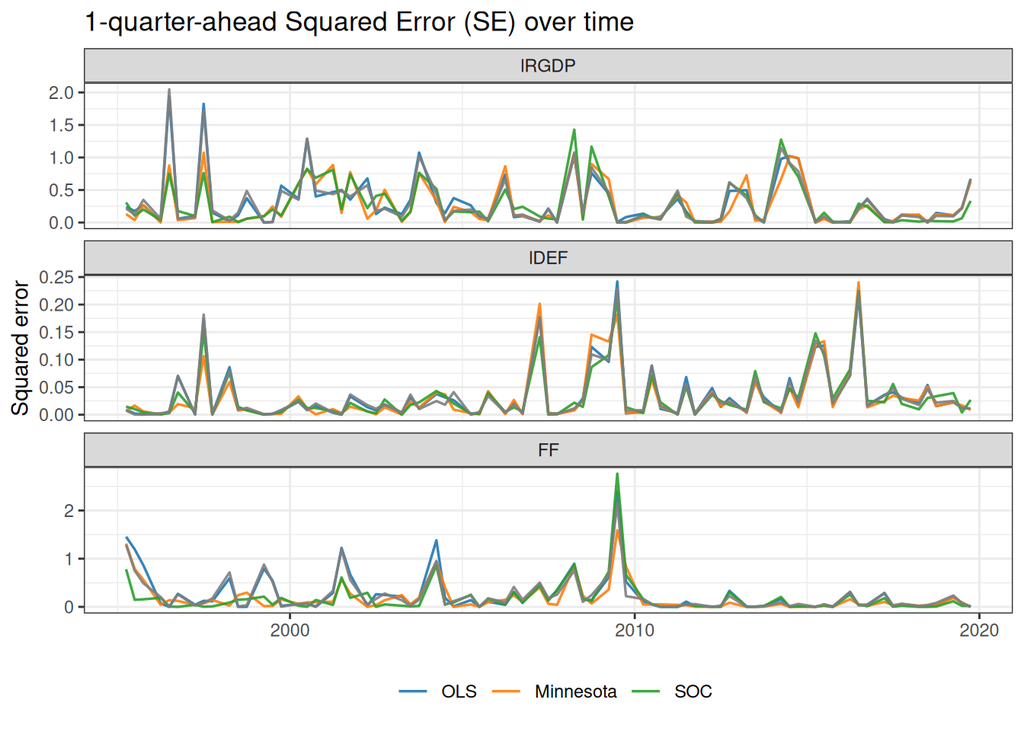

```r
df_se_long <- df_se %>%
  pivot_longer(
    cols = starts_with("se_"),
    names_to = "method",
    values_to = "se"
  ) %>%
  mutate(
    method = recode(method,
                    se_ols = "OLS",
                    se_mn  = "Minnesota",
                    se_soc = "SOC",
                    se_dobs = "Dummy Obs."),
    method = factor(method, levels = model_name),
    var    = factor(var, levels = vars)
  )

ggplot(df_se_long, aes(x = date, y = se, color = method)) +
  geom_line(linewidth = 0.6, alpha = 0.9) +
  facet_wrap(~ var, ncol = 1, scales = "free_y") +
  scale_color_manual(values = col_map_se) +
  labs(
    title = "1-quarter-ahead Squared Error (SE) over time",
    x = NULL, y = "Squared error",
    color = ""
  ) +
  theme_bw() +
  theme(legend.position = "bottom")
```

## 4.7 Natural Conjugate Prior

単回帰の自然共役分布：Normal-Gamma

SURの自然共役分布：Normal-Wishart

Why?

“一言でいうと（ChatGPT）”

- 単回帰

  $$\log L \;\sim\; \frac{T}{2}\log\sigma^{2} \;+\;
  \frac{1}{2\sigma^{2}}\,(y-X\beta)'(y-X\beta)$$
- SUR

  $$\log L \;\sim\; \frac{T}{2}\log|\Sigma| \;+\;
  \frac{1}{2}\,\mathrm{tr}\!\left(\Sigma^{-1}U'U\right)\quad\text{with
  } U=Y-XB,\; y=\mathrm{vec}(Y),\; \beta=\mathrm{vec}(B).$$

$\mathrm{tr}\!\left(\Sigma^{-1}U'U\right)$とは：

$$U'U=\begin{pmatrix}
\sum_{t=1}^4 u_{t1}^2 & \sum_{t=1}^4 u_{t1}u_{t2} & \sum_{t=1}^4
u_{t1}u_{t3}\\
\sum_{t=1}^4 u_{t2}u_{t1} & \sum_{t=1}^4 u_{t2}^2 & \sum_{t=1}^4
u_{t2}u_{t3}\\
\sum_{t=1}^4 u_{t3}u_{t1} & \sum_{t=1}^4 u_{t3}u_{t2} &
\sum_{t=1}^4 u_{t3}^2
\end{pmatrix}.$$
$$\mathrm{tr}\!\left(\Sigma^{-1}U'U\right)=\sum_{i=1}^3\sum_{j=1}^3
\omega_{ij}\sum_{t=1}^4 u_{ti}u_{tj}=\sum_{t=1}^4
\,u_t'\Sigma^{-1}u_t,\quad
u_t=\begin{pmatrix}u_{t1}\\u_{t2}\\u_{t3}\end{pmatrix}.$$

$$(\omega_{ij}=\omega_{ji}):\mathrm{tr}\!\left(\Sigma^{-1}U'U\right)=\sum_{t=1}^4\Big(\omega_{11}u_{t1}^2+\omega_{22}u_{t2}^2+\omega_{33}u_{t3}^2+2\omega_{12}u_{t1}u_{t2}+2\omega_{13}u_{t1}u_{t3}+2\omega_{23}u_{t2}u_{t3}\Big).$$

```r
# mu_0 <- 1
# mu_1 <- 1
# # mu_2 <- 1 "should be set to 1"
# mu_3 <- 1
# sigma <- c(1,1,1)
#
# Ydum <- matrix(0, nrow = K-1, ncol = M)
#
# diag(Ydum) <- mu_1 * mu_3 * sigma
```

各時点の残差ベクトルの二次形式を足しあげたもの。つまり、$\Sigma^{-1}$の非対角要素がある限り、交差項（e.g. $\sum_t u_{t1}u_{t2}$）が入る。 つまり、**尤度が方程式ごとに分解できない。**（c.f. $\Sigma$が対角なら、方程式ごとのOLS尤度の積に分解可能）

**Natural ConjugateでできないMinnesotaの例を考えてみる**（e.g. Killianの$\theta$、3変数以上の場合の$\sigma_i/\sigma_j$など？）

# 5 Koop & Korobilis (2010) と Kilian & Lütkepohl (2016) の notation の違い

Bayesian VAR のベクトル化表現は、Koop and Korobilis (2010, KK) と  
Kilian and Lütkepohl (2016, KL) で見かけ上異なる形で書かれているが、  
**適切な並べ替えを行えば数学的に完全に同値**である。

以下では、その違いと注意点を整理する。

##### 5.0.0.0.1 ベクトル化（vec）の取り方

- **KK**
  被説明変数行列 $Y$ に対して **列方向の vec** を取る：
  $$y = \mathrm{vec}(Y)
  =
  \begin{bmatrix}
  Y_{:,1} \\
  Y_{:,2} \\
  \vdots \\
  Y_{:,M}
  \end{bmatrix}$$
  （各方程式ごとに時間方向にスタック）
- **KL**  
  ブロック回帰の観点から、 **時間方向を先に並べた表現**を用いる。

この違いが、設計行列や誤差分散の Kronecker 積の順序の差として現れる。

##### 5.0.0.0.2 設計行列の違い

VAR($p$) を
$$Y = XA + E$$
と書くとき、

- **KK の表現**
  $$y = \underbrace{(I_M \otimes
  X)}_{\text{KK}} \alpha + e, \qquad \alpha = \mathrm{vec}(A)$$
- **KL の表現**
  $$y = \underbrace{(X \otimes I_M)}_{\text{KL}} \tilde{\alpha} + u$$

両者は、係数ベクトルの並び替え
$$\tilde{\alpha} = P \alpha$$
を用いれば同一の線形写像を表している。

##### 5.0.0.0.3 誤差分散行列の違い

- **KK**
  $$e \sim N(0,\; \Sigma \otimes I_T)$$
- **KL**
  $$u \sim N(0,\; I_T \otimes \Sigma)$$

これは誤差項の分布が異なるのではなく、  
**ベクトルの並び順の違いによる見かけの差**である。

行列正規分布
$$E \sim MN(0,\; I_T,\; \Sigma)$$
に対して、どの順序で vec を取るかによって
Kronecker 積の順序が入れ替わる。

##### 5.0.0.0.4 本質的に同値である理由

Kronecker 積と vec の基本恒等式により、
$$(I_M \otimes X)\,\mathrm{vec}(A)
\quad \text{と} \quad
(X \otimes I_M)\,P\,\mathrm{vec}(A)$$
は、適切な置換行列 $P$ の下で同一である。

したがって、KK と KL の違いは

> **モデルの違いではなく、表現（notation）の違い**

に過ぎない。

##### 5.0.0.0.5 実装上の重要な注意点

- 一度 **KK 流**（$I_M \otimes X$, $\Sigma \otimes I_T$）を採用したら、
  - 係数ベクトルの並び
  - dummy observation
  - GLS / whitening を **すべてその規約で統一**する必要がある。
- KL の式をそのままコードに写すと、
  - Kronecker 積の順序
  - 誤差分散の扱い が一致せず、誤った重み付けになる危険がある。

### 5.0.1 まとめ

- Koop and Korobilis (2010) と Kilian and Lütkepohl (2016) の VAR 表現は  
  **完全に同値**である。
- 違いは
  - vec の定義
  - 係数ベクトルの並び
  - Kronecker 積の順序 に起因する **記法上の差**である。
- 実装では、**どちらの規約を使うかを最初に決め、最後まで貫くことが必須**である。

# 6 7変数ver

```r
# --- packages: 既存に加えて zoo は already, quantmod already ---

# 四半期化ヘルパ：月次・日次でも四半期に落とす（デフォルトは四半期平均）
to_qtr_zoo <- function(x, agg = c("mean", "last")) {
  agg <- match.arg(agg)
  z <- zoo::zoo(as.numeric(x), zoo::as.yearmon(zoo::index(x)))  # month index
  # もし元が四半期や日次でも yearmon に落ちるので、年四半期へ集計できる
  if (agg == "mean") return(aggregate(z, zoo::as.yearqtr, mean, na.rm = TRUE))
  if (agg == "last") return(aggregate(z, zoo::as.yearqtr, function(v) tail(v, 1)))
}

# 7系列DL
getSymbols(c("GDPC1","GDPDEF","FEDFUNDS","PCECC96","GPDIC1","HOANBS","COMPRNFB"), src="FRED")

# 四半期系列（元が四半期でも「四半期へ強制」しておく）
rgdp_q  <- to_qtr_zoo(GDPC1,    agg = "mean")
def_q   <- to_qtr_zoo(GDPDEF,   agg = "mean")
ff_q    <- to_qtr_zoo(FEDFUNDS, agg = "mean")  # 金利は四半期平均が自然
c_q     <- to_qtr_zoo(PCECC96,  agg = "mean")
i_q     <- to_qtr_zoo(GPDIC1,   agg = "mean")
hours_q <- to_qtr_zoo(HOANBS,   agg = "mean")
comp_q  <- to_qtr_zoo(COMPRNFB, agg = "mean")

z_q <- na.omit(merge(rgdp_q, def_q, ff_q, c_q, i_q, hours_q, comp_q))
colnames(z_q) <- c("RGDP","DEF","FF","RC","RI","HOURS","RCOMP")

# 変換：あなたの既存方針に合わせる（log系は100*log、金利はlevel）
df_var7 <- tibble(
  date   = as.Date(as.yearqtr(index(z_q)), frac = 1),
  lRGDP  = 100*log(as.numeric(z_q[,"RGDP"])),
  lDEF   = 100*log(as.numeric(z_q[,"DEF"])),
  FF     = as.numeric(z_q[,"FF"]),
  lRC    = 100*log(as.numeric(z_q[,"RC"])),
  lRI    = 100*log(as.numeric(z_q[,"RI"])),
  lHOURS = 100*log(as.numeric(z_q[,"HOURS"])),
  lRCOMP = 100*log(as.numeric(z_q[,"RCOMP"]))
)

# 期間（既存を踏襲）
df_var_long <- df_var7 %>% filter(as.Date("1980-01-01") <= date, date <= as.Date("2019-12-31"))
df_var      <- df_var7 %>% filter(as.Date("1995-01-01") <= date, date <= as.Date("2019-12-31"))

vars7 <- c("lRGDP","lDEF","FF","lRC","lRI","lHOURS","lRCOMP")
```

```
## [1] "GDPC1"    "GDPDEF"   "FEDFUNDS" "PCECC96"  "GPDIC1"   "HOANBS"   "COMPRNFB"
```

```r
var_1step_fc <- function(train_df, vars, p, A, add_const = TRUE) {
  Ymat <- as.matrix(train_df[, vars, drop = FALSE])
  T_df <- nrow(Ymat); M <- length(vars)

  hist <- Ymat[T_df:(T_df - p + 1), , drop = FALSE]  # rows: t, t-1, ..., t-p+1
  x_no_const <- as.vector(t(hist))                   # lag1(vars) -> lag2(vars) -> ...
  x <- if (add_const) c(1, x_no_const) else x_no_const
  drop(x %*% A)
}

msfe_1step_expanding <- function(df_long, vars, p,
                                 train_start = as.Date("1980-01-01"),
                                 train_end0  = as.Date("1994-12-31"),
                                 mn_hyper   = list(a1 = 1, a2 = 0.5, a3 = 0.1),
                                 soc_hyper  = list(tau = 1),
                                 dobs_hyper = list(tau = 1)) {

  df_long <- df_long %>% arrange(date) %>% filter(train_start <= date)

  end_dates <- df_long$date[df_long$date >= train_end0]
  end_dates <- end_dates[end_dates <= (max(df_long$date) %m-% months(3))]

  out <- vector("list", length(end_dates))

  for (ii in seq_along(end_dates)) {
    t_end <- end_dates[ii]
    train <- df_long %>% filter(date <= t_end)
    test_date <- t_end %m+% months(3)
    test <- df_long %>% filter(date == test_date)

    if (nrow(test) != 1) next
    if (nrow(train) < (p + 10)) next

    A_ols  <- estimate_A_ols(train, vars, p)
    A_mn   <- do.call(estimate_A_mn_post, c(list(train_df=train, vars=vars, p=p), mn_hyper))
    A_soc  <- do.call(estimate_A_soc,     c(list(train_df=train, vars=vars, p=p), soc_hyper))
    A_dobs <- do.call(estimate_A_dobs,    c(list(train_df=train, vars=vars, p=p), dobs_hyper))

    fc_ols  <- var_1step_fc(train, vars, p, A_ols)
    fc_mn   <- var_1step_fc(train, vars, p, A_mn)
    fc_soc  <- var_1step_fc(train, vars, p, A_soc)
    fc_dobs <- var_1step_fc(train, vars, p, A_dobs)

    y_true <- as.numeric(test[1, vars])

    out[[ii]] <- tibble(
      date = test_date,
      var  = vars,
      se_ols  = (y_true - fc_ols)^2,
      se_mn   = (y_true - fc_mn)^2,
      se_soc  = (y_true - fc_soc)^2,
      se_dobs = (y_true - fc_dobs)^2
    )
  }

  df_se <- bind_rows(out)

  df_msfe <- df_se %>%
    group_by(var) %>%
    summarize(
      MSFE_OLS       = mean(se_ols,  na.rm = TRUE),
      MSFE_MN        = mean(se_mn,   na.rm = TRUE),
      MSFE_SOC       = mean(se_soc,  na.rm = TRUE),
      MSFE_DOBS      = mean(se_dobs, na.rm = TRUE),
      RMSE_OLS       = sqrt(MSFE_OLS),
      RMSE_MN        = sqrt(MSFE_MN),
      RMSE_SOC       = sqrt(MSFE_SOC),
      RMSE_DOBS      = sqrt(MSFE_DOBS),
      .groups="drop"
    )

  list(se = df_se, msfe = df_msfe)
}

# 実行（7変数）
p <- 5
res_msfe7 <- msfe_1step_expanding(df_var_long, vars = vars7, p = p, dobs_hyper = list(tau = 0.1), soc_hyper = list(tau = 0.1))
df_rmse7 <- res_msfe7$msfe
```

```r
df_rmse7
res_msfe$msfe
```

```
## # A tibble: 7 × 9
##   var    MSFE_OLS MSFE_MN MSFE_SOC MSFE_DOBS RMSE_OLS RMSE_MN RMSE_SOC RMSE_DOBS
##   <chr>     <dbl>   <dbl>    <dbl>     <dbl>    <dbl>   <dbl>    <dbl>     <dbl>
## 1 FF       0.602   0.396    0.419     0.601     0.776   0.629    0.647     0.775
## 2 lDEF     0.0452  0.0359   0.0405    0.0485    0.213   0.190    0.201     0.220
## 3 lHOURS   0.344   0.238    0.275     0.344     0.587   0.488    0.525     0.586
## 4 lRC      0.313   0.201    0.213     0.255     0.560   0.448    0.462     0.505
## 5 lRCOMP   1.32    1.07     1.14      1.24      1.15    1.04     1.07      1.11
## 6 lRGDP    0.386   0.316    0.289     0.364     0.621   0.562    0.538     0.603
## 7 lRI      9.05    6.97     6.01      9.01      3.01    2.64     2.45      3.00
## # A tibble: 3 × 5
##   var   MSFE_OLS MSFE_Minnesota MSFE_SOC MSFE_DummyObs
##   <chr>    <dbl>          <dbl>    <dbl>         <dbl>
## 1 FF      0.257          0.179    0.177         0.236
## 2 lDEF    0.0356         0.0327   0.0338        0.0353
## 3 lRGDP   0.316          0.264    0.271         0.311
```

https://www.r-econometrics.com/timeseries/bvar/

T: 73 samples: 76 terms (1960Q1-1978Q4) - 2 lags - 1 dlog p: 2 lags k: 3 vars (invest, income, cons)